# Linear Regression: Life Expectancy

By Sabrina

October 9, 2020

# **Linear Regression**

## Concept

Regression is one of the most important concepts used in machine learning. Regression analysis allows us to predict target variable *(y)* based on the value of one or multiple predictor variables *(x)*. The target variable is also known as an independent variable or label. On the other hand, predictor variables are also known as dependent variables.

The types of regressions are represented in the diagram:

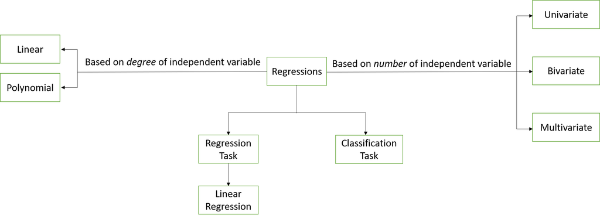

In the formula below you will find several notations, such as $y$, $b_0$, $b_n$, and $x_n$. Note that :

1. The target variable (independent variable) is denoted by $y$.
2. The predictor variables (dependent variables) are denoted by $x_n$.
3. The intercept is denoted by $b_0$.
4. The slope (gradient) values are denoted by $b_n$. The slope (gradient) value can have positive, negative or zero value. The slope (gradient) value need to be learnt.

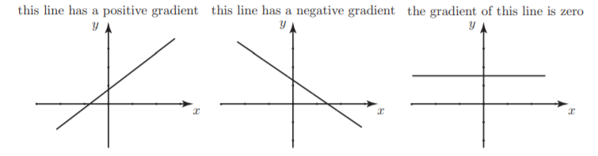

Without further ado, let’s talk in details about all the points shows in the block diagram!

### Based on:

### A. Degree of independent variable

1. Linear : the model fit to predict a target variable of the data is linear.

$$y = b_0 + b_1*x_1 + b_2*x_2 + b_3*x_3 + ... b_n*x_n$$

2. Polynomial: the model fit to predict a target variable of the data is polynomial.

$$y = b_0 + (b_1*x_1)^1 + (b_2*x_2)^2 + (b_3*x_3)^3 + ... (b_n*x_n)^n$$

### B. Number of independent variable

1. Univariate : the number of target variable (independent variable) is 1.

$$y = b_0 + b_1*x_1$$

2. Bivariate: the number of target variable (independent variable) is 2.

$$y = b_0 + b_1*x_1 + b_2*x_2$$

2. Multivariate: the number of target variable (independent variable) is more than 2.

$$y = b_0 + b_1*x_1 + b_2*x_2 + b_3*x_3 + ... b_n*x_n$$

### Linear Regression

The focus of the regression task is to predict a value of the best fit model based on the independent variable(s). The linear regression tries to find out the best possible linear relationship between the target variable and the predictor variables.

Linear regression consists of finding the best-fitting straight line through the points. The best-fitting line consists of the predicted score on $Y$ for each possible value of $X$. The vertical lines from the points to the best-fitting represent the errors of prediction.

The error of prediction for a point is the value of the point $Y$ minus the predicted value $Y'$ (the value on the line).

$$Error = Y - Y'$$

The most commonly-used criterion for the best-fitting line is the line that minimizes the sum of the squared errors of prediction ($(Y-Y')^2$).

## Limitations & Assumptions

### Limitations

Linear regression models, even when considered to be the powerhouse of statistics came with its limitations.

- Linear regressions are best fitted on data where a linear relationship between the predictor variables and target exist.
- Simple/multiple regression models can be sensitive to outliers (recall the chapter regarding leverage and power)

### Assumptions

Linear regression models, even when considered to be the powerhouse of statistics came with its assumptions.

1. Linearity: There’s a linear relationship between the target variable and the independet variable(s)

2. Normality Error: The distribution of error is a normal distribution.

3. Homoscedasticity: Error are randomly scattered

4. Non-Multicolinearity: There are no independent variable that are strongly correlated with each other.

# **Packages Required**

Initially, we begin by loading the packages that will be required throughout the course of the analysis.

```r
library(data.table)
library(DT)
library(kableExtra)
library(knitr)
library(tidyverse)
library(scales)
library(caret)
library(psych)
library(stats)
library(leaps)
library(GGally)
library(MASS)
library(lmtest)
library(car)
library(MLmetrics)
```

The descriptions of the packages are in the table below.

| Packages | Description |
| --- | --- |
| data.table | For data manipulation that can be reducing programming and compute time tremendously |
| DT | An R interface to the DataTables library |
| kableExtra | Styling an Interactive Data Tables within Markdown |
| knitr | A general-purpose tool for dynamic report generation |
| tidyverse | Collection of R packages (tidyr, dplyr, ggplot2) designed for data science that works harmoniously with other packages |
| tidyr | Changing the layout of the data sets, to convert data into a tidy format |
| dplyr | For data manipulation |
| ggplot2 | Customizable graphical representation |
| caret | For data Pre-Processing and Feature Selection |
| psych | Functions are primarily for multivariate analysis and scale construction using factor analysis, principal component analysis, cluster analysis and reliability analysis |
| stats | Contains functions for statistical calculations and random number generation. |
| leaps | Regression subset selection, including exhaustive search |
| GGally | Extends ‘ggplot2’ by adding several functions to reduce the complexity of combining geometric objects with transformed data. |
| MASS | Functions to support Venables and Ripley, ``Modern Applied Statistics with S’’ (4th edition, 2002) |
| lmtest | A collection of testsfor diagnostic checking in linear regression models. Furthermore, some generic tools for inference in parametric models are provided. |
| car | Functions to Accompany J. Fox and S. Weisberg, An R Companion to Applied Regression, Third Edition, Sage, 2019. |
| MLmetrics | A collection of evaluation metrics, including loss, score and utility functions, that measure regression, classification and ranking performance. |

# **Data Preparation**

Now, let’s load the dataset into the R-Environment.

## Importing Data

#### This project aims to build the best model that can predict the Life Expectancy based on he Global Health Observatory (GHO) dataset.

## Data Source

This project uses the data from [Kumar Rajarshi - Life Expectancy (WHO)](https://www.kaggle.com/kumarajarshi/life-expectancy-who) in kaggle.com website. The data was collected from WHO and United Nations website with the help of Deeksha Russell and Duan Wang.

[The Global Health Observatory (GHO) data repository](https://apps.who.int/gho/data/node.main.688) under World Health Organization (WHO) keeps track of the health status as well as many other related factors for all countries The data-sets are made available to public for the purpose of health data analysis. The data-set related to life expectancy, health factors for 193 countries has been collected from the same WHO data repository website and its corresponding economic data was collected from United Nation website. Among all categories of health-related factors only those critical factors were chosen which are more representative. It has been observed that in the past 15 years , there has been a huge development in health sector resulting in improvement of human mortality rates especially in the developing nations in comparison to the past 30 years. Therefore, in this project we have considered data from year 2000-2015 for 193 countries for further analysis. The individual data files have been merged together into a single data-set.

## Read the Data

The dataset is in `.csv` format, so we will use`read.csv` method to read the dataset.

```r
raw.data <- read.csv("assets/Life Expectancy Data.csv")
```

## Glimpse of the Data

After importing the dataset, Let’s take a peek of our dataset!

The dataset has **2,938 rows** and **22 columns**.

```r
# DATA INPUT: RAW DATASET
glimpse(raw.data)
```

```
## Rows: 2,938
## Columns: 22
## $ Country                         <chr> "Afghanistan", "Afghanistan", "Afgh...
## $ Year                            <int> 2015, 2014, 2013, 2012, 2011, 2010,...
## $ Status                          <chr> "Developing", "Developing", "Develo...
## $ Life.expectancy                 <dbl> 65.0, 59.9, 59.9, 59.5, 59.2, 58.8,...
## $ Adult.Mortality                 <int> 263, 271, 268, 272, 275, 279, 281, ...
## $ infant.deaths                   <int> 62, 64, 66, 69, 71, 74, 77, 80, 82,...
## $ Alcohol                         <dbl> 0.01, 0.01, 0.01, 0.01, 0.01, 0.01,...
## $ percentage.expenditure          <dbl> 71.279624, 73.523582, 73.219243, 78...
## $ Hepatitis.B                     <int> 65, 62, 64, 67, 68, 66, 63, 64, 63,...
## $ Measles                         <int> 1154, 492, 430, 2787, 3013, 1989, 2...
## $ BMI                             <dbl> 19.1, 18.6, 18.1, 17.6, 17.2, 16.7,...
## $ under.five.deaths               <int> 83, 86, 89, 93, 97, 102, 106, 110, ...
## $ Polio                           <int> 6, 58, 62, 67, 68, 66, 63, 64, 63, ...
## $ Total.expenditure               <dbl> 8.16, 8.18, 8.13, 8.52, 7.87, 9.20,...
## $ Diphtheria                      <int> 65, 62, 64, 67, 68, 66, 63, 64, 63,...
## $ HIV.AIDS                        <dbl> 0.1, 0.1, 0.1, 0.1, 0.1, 0.1, 0.1, ...
## $ GDP                             <dbl> 584.25921, 612.69651, 631.74498, 66...
## $ Population                      <dbl> 33736494, 327582, 31731688, 3696958...
## $ thinness..1.19.years            <dbl> 17.2, 17.5, 17.7, 17.9, 18.2, 18.4,...
## $ thinness.5.9.years              <dbl> 17.3, 17.5, 17.7, 18.0, 18.2, 18.4,...
## $ Income.composition.of.resources <dbl> 0.479, 0.476, 0.470, 0.463, 0.454, ...
## $ Schooling                       <dbl> 10.1, 10.0, 9.9, 9.8, 9.5, 9.2, 8.9...
```

## Data Wrangling

### Quality Check

#### Missing Values

Let’s see how many missing values in each column.

```r
# Counting missing values in each column
numMissVal <-sapply(raw.data, function(x) sum(length(which(is.na(x)))))

# Result table
kable(as.data.frame(numMissVal)) %>%
  kable_styling(bootstrap_options = c("striped", "hover", "condensed", "responsive")) %>%
  scroll_box(width = "100%", height = "250px")
```

|  | numMissVal |
| --- | --- |
| Country | 0 |
| Year | 0 |
| Status | 0 |
| Life.expectancy | 10 |
| Adult.Mortality | 10 |
| infant.deaths | 0 |
| Alcohol | 194 |
| percentage.expenditure | 0 |
| Hepatitis.B | 553 |
| Measles | 0 |
| BMI | 34 |
| under.five.deaths | 0 |
| Polio | 19 |
| Total.expenditure | 226 |
| Diphtheria | 19 |
| HIV.AIDS | 0 |
| GDP | 448 |
| Population | 652 |
| thinness..1.19.years | 34 |
| thinness.5.9.years | 34 |
| Income.composition.of.resources | 167 |
| Schooling | 163 |

**Observation findings :**

1. The majority of columns have missing values.

#### Duplicated Rows

There aren’t any duplicated rows found.

```r
# Check duplicated rows
raw.data[which(duplicated(raw.data) ==T), ]
```

### Data Formatting

Some columns need to be changed as factors.

```r
# data format : factor
raw.data$Country <- as.factor(raw.data$Country)
raw.data$Status <-  as.factor(raw.data$Status)
```

### NA Values Treatment

#### Concept

The missing value can severely distort the distribution of the data. However, there isn’t any better way to deal with missing data. Removing columns or rows with missing values can produce a bias in the analysis. Note that imputation does not necessarily give better results.

[Alvira Swalin](https://towardsdatascience.com/@aswalin) gave a better explanation about how to handle missing data in [towardsdatascience.com](https://towardsdatascience.com/how-to-handle-missing-data-8646b18db0d4). The methods to handle missing values are as follow:

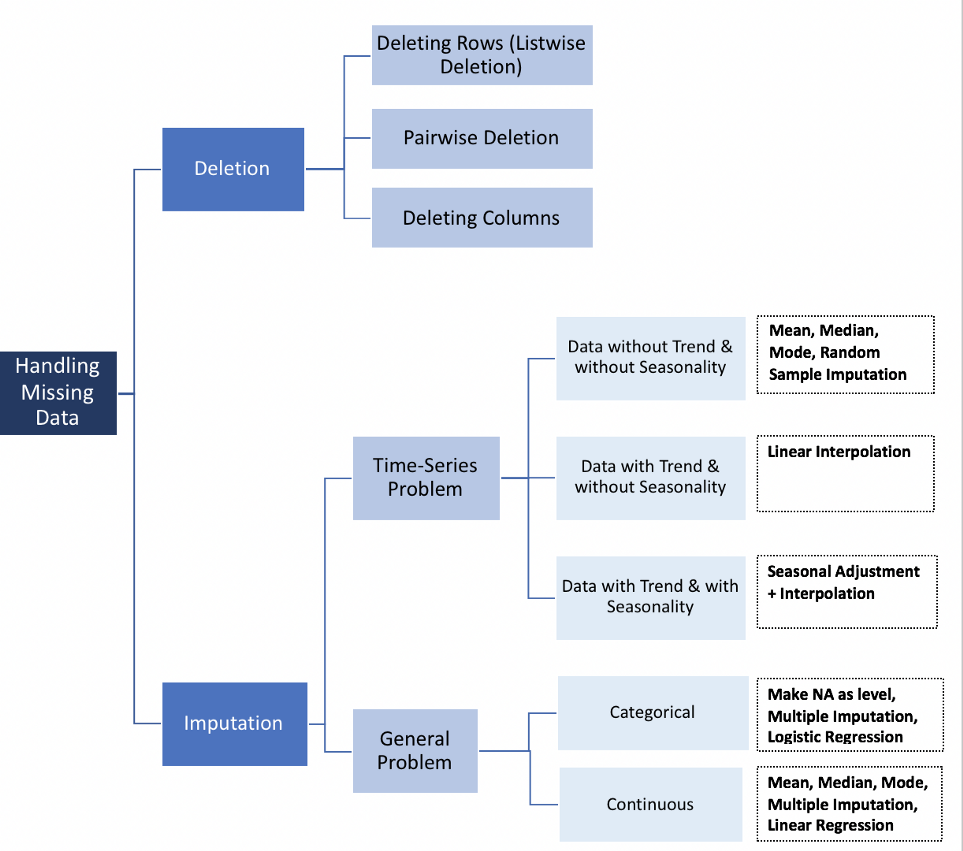

**Based on the previous flowchart, we use data imputation to deal with the general problem with continuous data type.**

#### Check Outliers

According to the block diagram before, we can treat the missing values by using data imputation. The columns that have missing values are continuous data type. To treat the missing value, we can choose to treat it by imputing its mean value or its median value based on the outliers occurrences. If there are many outliers data, it’ll be best to use the median value. On the other hand, if there aren’t many outliers data, we can use the mean value.

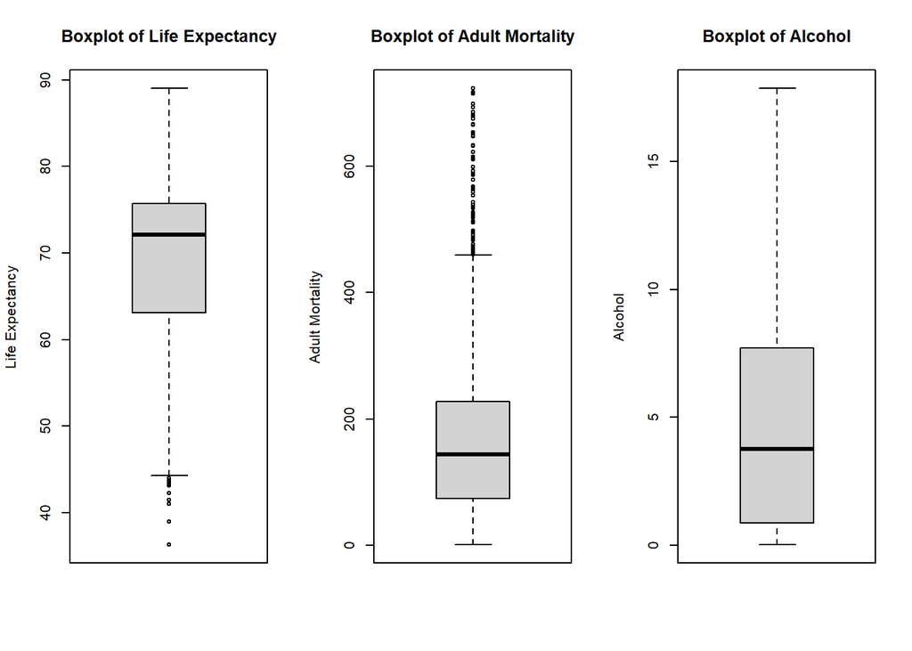

```r
par(mfrow=c(1,3))
boxplot(raw.data$Life.expectancy,
        ylab = "Life Expectancy",
        main = "Boxplot of Life Expectancy")
boxplot(raw.data$Adult.Mortality,
        ylab = "Adult Mortality",
        main = "Boxplot of Adult Mortality")
boxplot(raw.data$Alcohol,
        ylab = "Alcohol",
        main = "Boxplot of Alcohol")
```

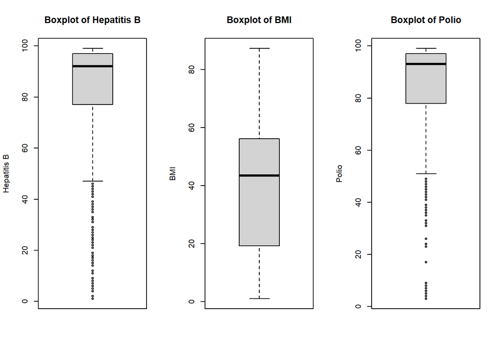

```r
par(mfrow=c(1,3))
boxplot(raw.data$Hepatitis.B,
        ylab = "Hepatitis B",
        main = "Boxplot of Hepatitis B")
boxplot(raw.data$BMI,
        ylab = "BMI",
        main = "Boxplot of BMI")
boxplot(raw.data$Polio,
        ylab = "Polio",
        main = "Boxplot of Polio")
```

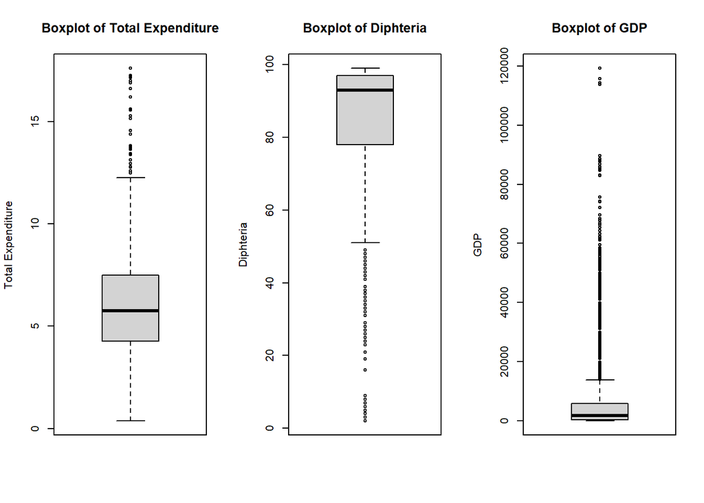

```r
par(mfrow=c(1,3))
boxplot(raw.data$Total.expenditure,
        ylab = "Total Expenditure",
        main = "Boxplot of Total Expenditure")
boxplot(raw.data$Diphtheria,
        ylab = "Diphteria",
        main = "Boxplot of Diphteria")
boxplot(raw.data$GDP,
        ylab = "GDP",
        main = "Boxplot of GDP")
```

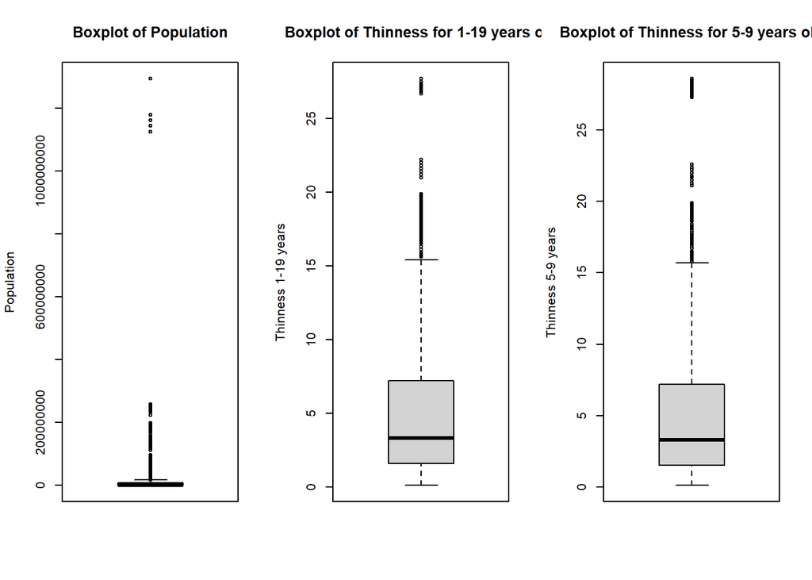

```r
par(mfrow=c(1,3))
boxplot(raw.data$Population,
        ylab = "Population",
        main = "Boxplot of Population")
boxplot(raw.data$thinness..1.19.years,
        ylab = "Thinness 1-19 years",
        main = "Boxplot of Thinness for 1-19 years old")
boxplot(raw.data$thinness.5.9.years,
        ylab = "Thinness 5-9 years",
        main = "Boxplot of Thinness for 5-9 years old")
```

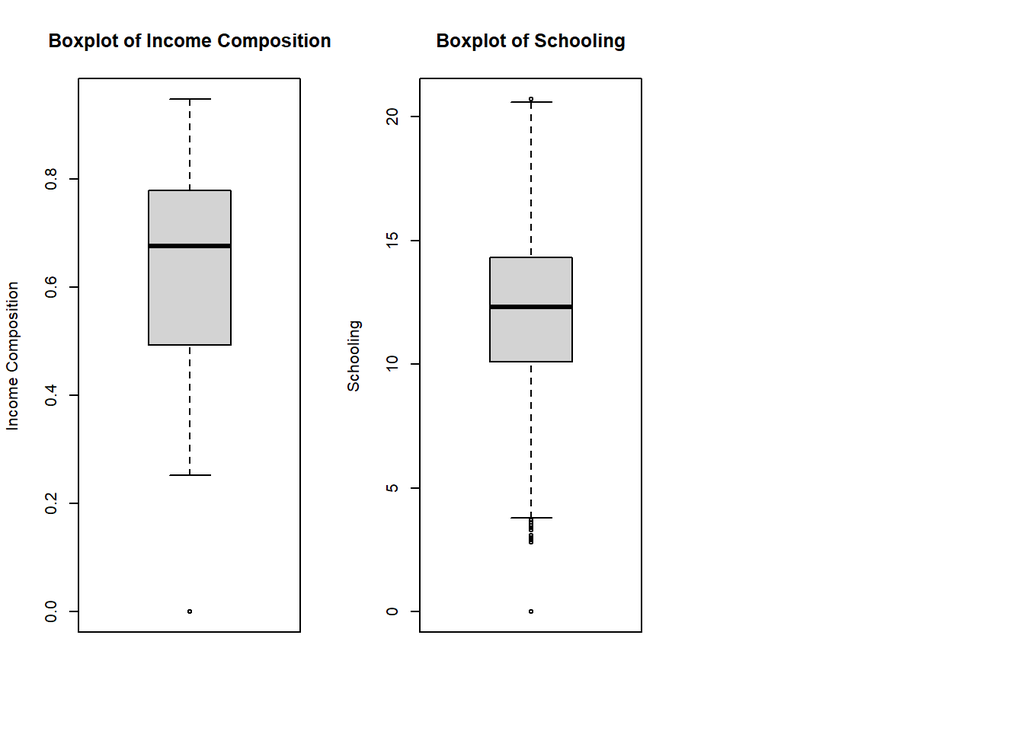

```r
par(mfrow=c(1,3))
boxplot(raw.data$Income.composition.of.resources,
        ylab = "Income Composition",
        main = "Boxplot of Income Composition")
boxplot(raw.data$Schooling,
        ylab = "Schooling",
        main = "Boxplot of Schooling")
```

**Observation findings :**

1. Most of the columns have many outliers, except `Alcohol`, `BMI`, `Income.composition.of.resources`.
2. We use its median value for the columns that have many outliers.
3. We use its mean value for the columns that not have many outliers.

#### Data Imputation

We use data imputation by its median value to most of the columns with missing values. These columns have many outliers.

```r
# Find median value

life_mean <- median(raw.data$Life.expectancy,  na.rm = TRUE)
mortality_mean <- median(raw.data$Adult.Mortality,  na.rm = TRUE)
hepatitis_mean <- median(raw.data$Hepatitis.B,  na.rm = TRUE)
polio_mean <- median(raw.data$Polio,  na.rm = TRUE)
diph_mean <- median(raw.data$Diphtheria,  na.rm = TRUE)
exp_mean <- median(raw.data$Total.expenditure,  na.rm = TRUE)
gdp_mean <- median(raw.data$GDP,  na.rm = TRUE)
pop_mean <- median(raw.data$Population,  na.rm = TRUE)
thin19_mean <- median(raw.data$thinness..1.19.years,  na.rm = TRUE)
thin9_mean <- median(raw.data$thinness.5.9.years,  na.rm = TRUE)
school_mean <- median(raw.data$Schooling,  na.rm = TRUE)
```

Then replace the missing values with the median of the corresponding columns.

```r
raw.data$Life.expectancy[is.na(raw.data$Life.expectancy)] <- life_mean
raw.data$Adult.Mortality[is.na(raw.data$Adult.Mortality)] <- mortality_mean
raw.data$Hepatitis.B[is.na(raw.data$Hepatitis.B)] <- hepatitis_mean
raw.data$Polio[is.na(raw.data$Polio)] <- polio_mean
raw.data$Diphtheria[is.na(raw.data$Diphtheria)] <- diph_mean
raw.data$Total.expenditure[is.na(raw.data$Total.expenditure)] <- exp_mean
raw.data$GDP[is.na(raw.data$GDP)] <- gdp_mean
raw.data$Population[is.na(raw.data$Population)] <- pop_mean
raw.data$thinness..1.19.years[is.na(raw.data$thinness..1.19.years)] <- thin19_mean
raw.data$thinness.5.9.years[is.na(raw.data$thinness.5.9.years)] <- thin9_mean
raw.data$Schooling[is.na(raw.data$Schooling)] <- school_mean
```

Next, we find the mean value for the `Alcohol`, `BMI`, `Income.composition.of.resources` columns. These columns don’t have many outliers.

```r
alcohol_mean <- mean(raw.data$Alcohol,  na.rm = TRUE)
bmi_mean <- mean(raw.data$BMI,  na.rm = TRUE)
income_mean <- mean(raw.data$Income.composition.of.resources,  na.rm = TRUE)
```

Then replace the missing values with the average of the corresponding columns.

```r
raw.data$Alcohol[is.na(raw.data$Alcohol)] <- alcohol_mean
raw.data$BMI[is.na(raw.data$BMI)] <- bmi_mean
raw.data$Income.composition.of.resources[is.na(raw.data$Income.composition.of.resources)] <- income_mean
```

## Cleaned Dataset

Here’s the cleaned data set:

```r
datatable(head(clean_data, 50),
          options = list(scroller = TRUE, scrollX = T),
          style = 'bootstrap',
          class = 'table-bordered table-condensed')
```

|  | Country | Year | Status | Life.expectancy | Adult.Mortality | infant.deaths | Alcohol | percentage.expenditure | Hepatitis.B | Measles | BMI | under.five.deaths | Polio | Total.expenditure | Diphtheria | HIV.AIDS | GDP | Population | thinness..1.19.years | thinness.5.9.years | Income.composition.of.resources | Schooling |
| --- | --- | --- | --- | --- | --- | --- | --- | --- | --- | --- | --- | --- | --- | --- | --- | --- | --- | --- | --- | --- | --- | --- |
| 1 | Afghanistan | 2015 | Developing | 65 | 263 | 62 | 0.01 | 71.27962362 | 65 | 1154 | 19.1 | 83 | 6 | 8.16 | 65 | 0.1 | 584.25921 | 33736494 | 17.2 | 17.3 | 0.479 | 10.1 |
| 2 | Afghanistan | 2014 | Developing | 59.9 | 271 | 64 | 0.01 | 73.52358168 | 62 | 492 | 18.6 | 86 | 58 | 8.18 | 62 | 0.1 | 612.696514 | 327582 | 17.5 | 17.5 | 0.476 | 10 |
| 3 | Afghanistan | 2013 | Developing | 59.9 | 268 | 66 | 0.01 | 73.21924272 | 64 | 430 | 18.1 | 89 | 62 | 8.13 | 64 | 0.1 | 631.744976 | 31731688 | 17.7 | 17.7 | 0.47 | 9.9 |
| 4 | Afghanistan | 2012 | Developing | 59.5 | 272 | 69 | 0.01 | 78.1842153 | 67 | 2787 | 17.6 | 93 | 67 | 8.52 | 67 | 0.1 | 669.959 | 3696958 | 17.9 | 18 | 0.463 | 9.8 |
| 5 | Afghanistan | 2011 | Developing | 59.2 | 275 | 71 | 0.01 | 7.097108703 | 68 | 3013 | 17.2 | 97 | 68 | 7.87 | 68 | 0.1 | 63.537231 | 2978599 | 18.2 | 18.2 | 0.454 | 9.5 |
| 6 | Afghanistan | 2010 | Developing | 58.8 | 279 | 74 | 0.01 | 79.67936736 | 66 | 1989 | 16.7 | 102 | 66 | 9.2 | 66 | 0.1 | 553.32894 | 2883167 | 18.4 | 18.4 | 0.448 | 9.2 |
| 7 | Afghanistan | 2009 | Developing | 58.6 | 281 | 77 | 0.01 | 56.76221682 | 63 | 2861 | 16.2 | 106 | 63 | 9.42 | 63 | 0.1 | 445.8932979 | 284331 | 18.6 | 18.7 | 0.434 | 8.9 |
| 8 | Afghanistan | 2008 | Developing | 58.1 | 287 | 80 | 0.03 | 25.87392536 | 64 | 1599 | 15.7 | 110 | 64 | 8.33 | 64 | 0.1 | 373.3611163 | 2729431 | 18.8 | 18.9 | 0.433 | 8.7 |
| 9 | Afghanistan | 2007 | Developing | 57.5 | 295 | 82 | 0.02 | 10.91015598 | 63 | 1141 | 15.2 | 113 | 63 | 6.73 | 63 | 0.1 | 369.835796 | 26616792 | 19 | 19.1 | 0.415 | 8.4 |
| 10 | Afghanistan | 2006 | Developing | 57.3 | 295 | 84 | 0.03 | 17.17151751 | 64 | 1990 | 14.7 | 116 | 58 | 7.43 | 58 | 0.1 | 272.56377 | 2589345 | 19.2 | 19.3 | 0.405 | 8.1 |

[output cut: 40 more lines]

## Summary of Variables

The summary of the variables of dataset are in the table below.

| No. | Variable | Class | Description |
| --- | --- | --- | --- |
| 1 | Country | factor | Country name |
| 2 | Year | numeric | Year of the data |
| 3 | Status | factor | Country status of developed or developing |
| 4 | Life_Expectancy | numeric | Life expectancy in age |
| 5 | Adult_Mortality | numeric | Adult Mortality Rates of both sexes (probability of dying between 15 and 60 years per 1000 population) |
| 6 | infant.deaths | numeric | Number of Infant Deaths per 1000 population |
| 7 | Alcohol | numeric | Alcohol, recorded per capita (15+) consumption (in litres of pure alcohol) |
| 8 | percentage.expenditure | numeric | Expenditure on health as a percentage of Gross Domestic Product per capita(%) |
| 9 | Hepatitis.B | numeric | Hepatitis B (HepB) immunization coverage among 1-year-olds (%) |
| 10 | Measles | numeric | Measles - number of reported cases per 1000 population |
| 11 | BMI | numeric | Average Body Mass Index of entire population |
| 12 | under.five.deaths | numeric | Number of under-five deaths per 1000 population |
| 13 | Polio | numeric | Polio (Pol3) immunization coverage among 1-year-olds (%) |
| 14 | Total.expenditure | numeric | General government expenditure on health as a percentage of total government expenditure (%) |
| 15 | Diphtheria | numeric | Diphtheria tetanus toxoid and pertussis (DTP3) immunization coverage among 1-year-olds (%)room) |
| 16 | HIV.AIDS | numeric | Deaths per 1 000 live births HIV/AIDS (0-4 years) |
| 17 | GDP | numeric | Gross Domestic Product per capita (in USD) |
| 18 | Population | numeric | Population of the country |
| 19 | thinness..1.19.years | numeric | Prevalence of thinness among children and adolescents for Age 10 to 19 (% ) |
| 20 | thinness.5.9.years | numeric | Prevalence of thinness among children for Age 5 to 9(%) |
| 21 | Income.composition.of.resources | numeric | Human Development Index in terms of income composition of resources (index ranging from 0 to 1) |
| 22 | Schooling | numeric | Number of years of Schooling(years) |

# **Explanatory Data Analysis**

## Target Variable

In this study case, we use `Life.Expectancy` as our target variable. Let’s do EDA on the target variable.

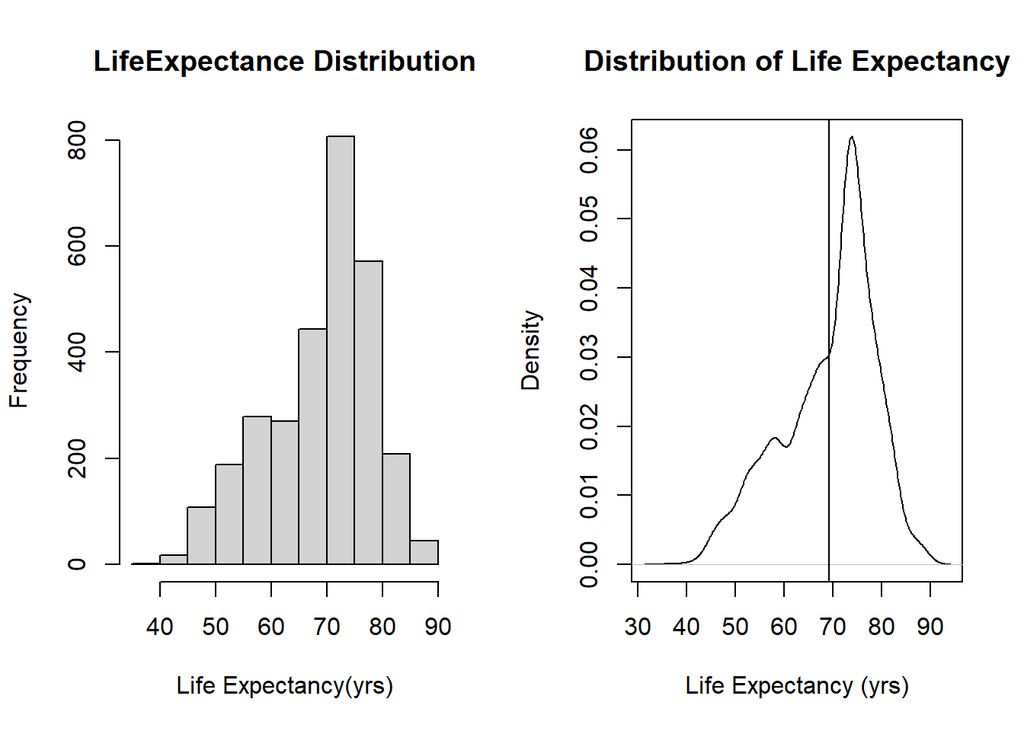

```r
par(mfrow=c(1,2))
# target variable
# histogram
hist(clean_data$Life.expectancy,
     main = "LifeExpectance Distribution",
     xlab = "Life Expectancy(yrs)")
# kernel density plot with a vertical indication of location of the mean
plot(density(clean_data$Life.expectancy),
     main = "Distribution of Life Expectancy",
     xlab = "Life Expectancy (yrs)")
abline(v=mean(clean_data$Life.expectancy))
```

**Observation findings :**

1. the target variable `Life.expectancy` is not distributed perfectly normal, it is a little left-skewed.
2. The unit of Life Expectancy is number of years.

## Predictor Variables

### Univariate Plots

#### Alcohol

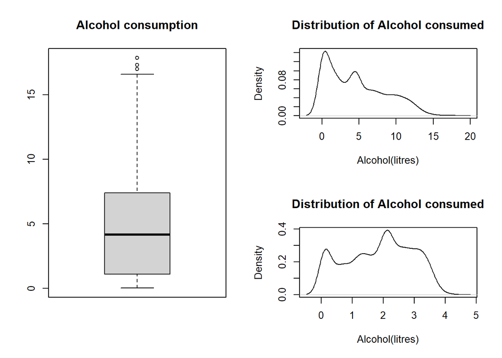

```r
par(mfrow=c(2,2))
layout(matrix(c(1,1,2,3), 2, 2, byrow = F),
   widths=c(1,1), heights=c(1,1))
boxplot(clean_data$Alcohol,
        main = "Alcohol consumption")         # box plot
plot(density(clean_data$Alcohol),
     main = "Distribution of Alcohol consumed",
     xlab = "Alcohol(litres)")   # kernel density plot
# to normalize the density plot
plot(density(clean_data$Alcohol^0.5),
     main = "Distribution of Alcohol consumed",
     xlab = "Alcohol(litres)")   # normalized kernel density plot
```

**Observation findings :**

1. The predictor variable `Alcohol` is not normally distributed. It is highly right-skewed.
2. The outliers are not due to any data error, but just abnormal values due to some countries being having high GDP, whereas some countries having a very low GDP. Thus, they cannot be eliminated.
   - *proof: `Alcohol` and `GDP` are significantly correlated with a correlation coefficient of 0.31 and p-value of $2.2^{-16}$*

```r
cor.test(clean_data$Alcohol, clean_data$GDP)
##
##  Pearson's product-moment correlation
##
## data:  clean_data$Alcohol and clean_data$GDP
## t = 17.831, df = 2936, p-value < 0.00000000000000022
## alternative hypothesis: true correlation is not equal to 0
## 95 percent confidence interval:
##  0.2795771 0.3448433
## sample estimates:
##       cor
## 0.3125791
```

#### Under Five Year Old Deaths

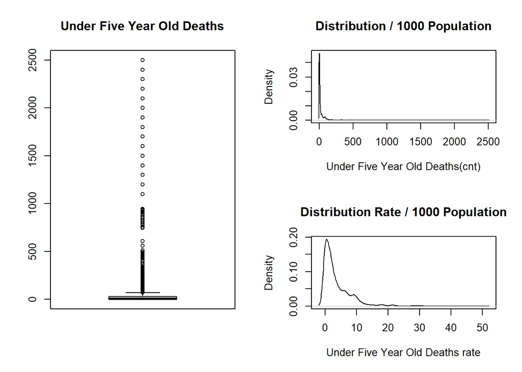

```r
par(mfrow=c(2,2))
layout(matrix(c(1,1,2,3), 2, 2, byrow = F),
   widths=c(1,1), heights=c(1,1))
boxplot(clean_data$under.five.deaths,
        main = "Under Five Year Old Deaths")         # box plot
plot(density(clean_data$under.five.deaths),
     main = "Distribution / 1000 Population",
     xlab = "Under Five Year Old Deaths(cnt)")   # kernel density plot
# to normalize the density plot
plot(density(clean_data$under.five.deaths^0.5),
     main = "Distribution Rate / 1000 Population",
     xlab = "Under Five Year Old Deaths rate")   # normalized kernel density plot
```

```r
cor.test(clean_data$under.five.deaths, clean_data$GDP)
##
##  Pearson's product-moment correlation
##
## data:  clean_data$under.five.deaths and clean_data$GDP
## t = -5.7813, df = 2936, p-value = 0.000000008194
## alternative hypothesis: true correlation is not equal to 0
## 95 percent confidence interval:
##  -0.14171143 -0.07020008
## sample estimates:
##        cor
## -0.1060929
```

#### Percentage Expenditure

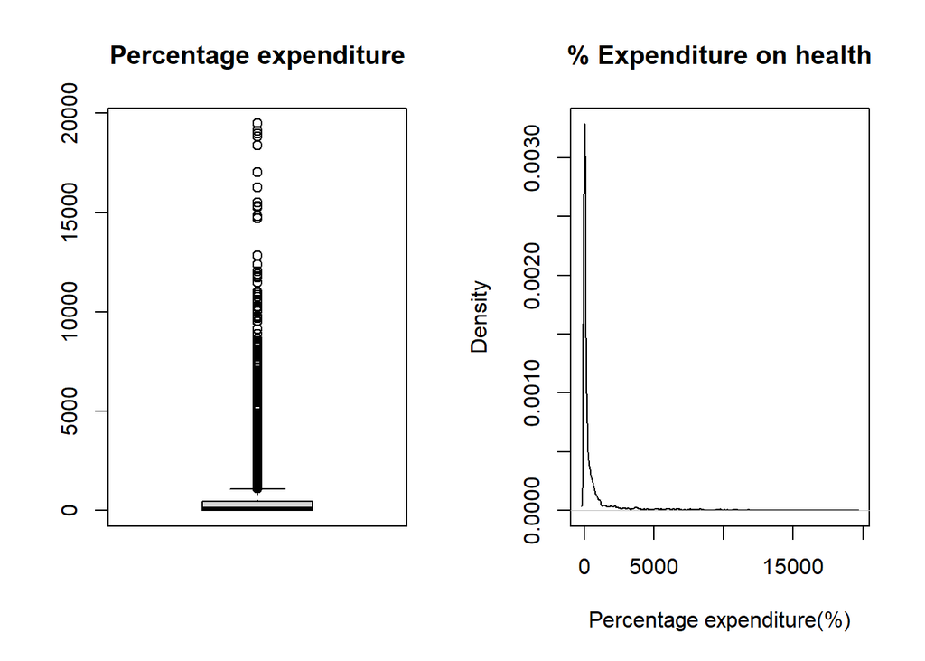

```r
par(mfrow=c(1,2))
boxplot(clean_data$percentage.expenditure,
        main = "Percentage expenditure")         # box plot
plot(density(clean_data$percentage.expenditure),
     main = "% Expenditure on health",
     xlab = "Percentage expenditure(%)")   # kernel density plot
```

**Observation findings :**

1. The predictor variable `percentage.expenditure` is not normally distributed. It is heavily right-skewed.
2. The outliers are not due to any data error, but just abnormal values due to some countries being having high GDP, whereas some countries having a very low GDP. Thus, they cannot be eliminated.
   - *proof: `percentage.expenditure` and `GDP` are significantly correlated with a correlation coefficient of 0.9 and p-value of $2.2^{-16}$*

```r
cor.test(clean_data$percentage.expenditure, clean_data$GDP)
##
##  Pearson's product-moment correlation
##
## data:  clean_data$percentage.expenditure and clean_data$GDP
## t = 113.08, df = 2936, p-value < 0.00000000000000022
## alternative hypothesis: true correlation is not equal to 0
## 95 percent confidence interval:
##  0.8948392 0.9083581
## sample estimates:
##       cor
## 0.9018191
```

#### Polio

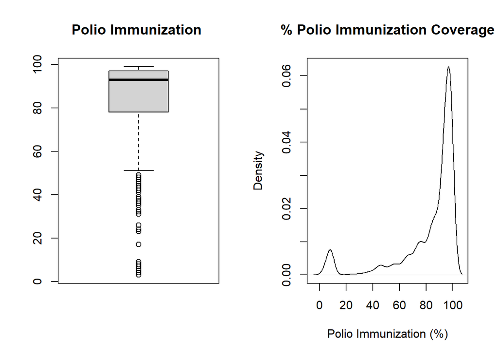

```r
par(mfrow=c(1,2))
boxplot(clean_data$Polio,
        main = "Polio Immunization ")         # box plot
plot(density(clean_data$Polio),
     main = "% Polio Immunization Coverage",
     xlab = "Polio Immunization (%)")   # kernel density plot
```

**Observation findings :**

1. The predictor variable `Polio` is not normally distributed. It is heavily left-skewed.
2. The outliers are not due to any data error, but just abnormal values due to some countries being having high GDP, whereas some countries having a very low GDP. Thus, they cannot be eliminated.
   - *proof: `Polio` and `GDP` are significantly correlated with a correlation coefficient of 0.18 and p-value of $2.2^{-16}$*

```r
cor.test(clean_data$Polio, clean_data$GDP)
##
##  Pearson's product-moment correlation
##
## data:  clean_data$Polio and clean_data$GDP
## t = 10.482, df = 2936, p-value < 0.00000000000000022
## alternative hypothesis: true correlation is not equal to 0
## 95 percent confidence interval:
##  0.1548269 0.2245457
## sample estimates:
##       cor
## 0.1899257
```

#### Prevalence of Thinness for Age 10 to 19

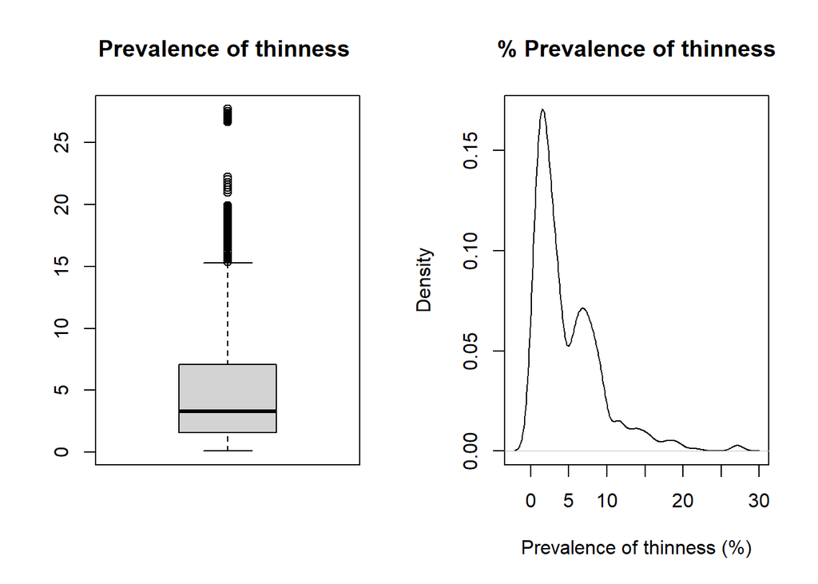

```r
par(mfrow=c(1,2))
boxplot(clean_data$thinness..1.19.years,
        main = "Prevalence of thinness ")         # box plot
plot(density(clean_data$thinness..1.19.years),
     main = "% Prevalence of thinness",
     xlab = "Prevalence of thinness (%)")   # kernel density plot
```

**Observation findings :**

1. The predictor variable `thinness..1.19.years` is not normally distributed. It is right-skewed.
2. The outliers are not due to any data error, but just abnormal values due to some countries being having high GDP, whereas some countries having a very low GDP. Thus, they cannot be eliminated.
   - *proof: `thinness..1.19.years` and `GDP` are significantly correlated with a correlation coefficient of -0.26 and p-value of $2.2^{-16}$*

```r
cor.test(clean_data$thinness..1.19.years, clean_data$GDP)
##
##  Pearson's product-moment correlation
##
## data:  clean_data$thinness..1.19.years and clean_data$GDP
## t = -14.79, df = 2936, p-value < 0.00000000000000022
## alternative hypothesis: true correlation is not equal to 0
## 95 percent confidence interval:
##  -0.2966604 -0.2293449
## sample estimates:
##        cor
## -0.2633231
```

### Bivariate Plots

#### Life Expectancy ~ Income Compositions

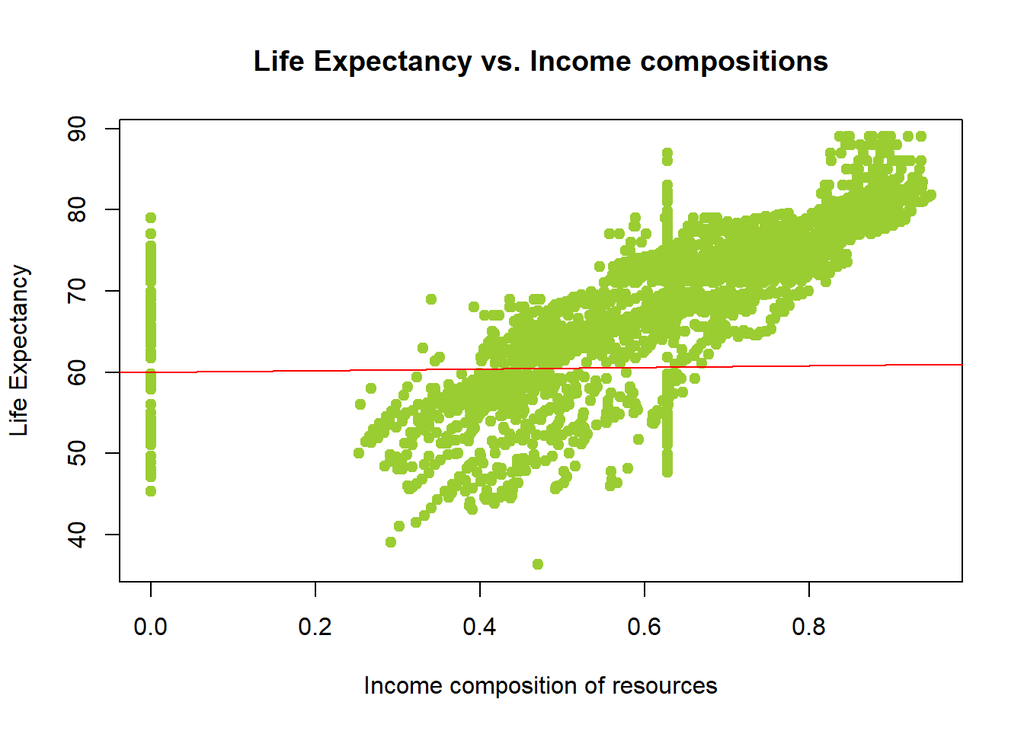

```r
# life expectancy vs. income composition - positively correlated
plot(y = clean_data$Life.expectancy,
     x = clean_data$Income.composition.of.resources,
     main = "Life Expectancy vs. Income compositions",
     xlab = "Income composition of resources",
     ylab = "Life Expectancy",
     pch = 19,
     col = "yellowgreen")
abline(60,1,
       col = "red")       # 45 degree line (line with slope 1)
```

**Observation findings :**

1. The `Life.expectancy` and `Income.composition.of.resources` are positively correlated.
2. The red line in the plot indicates a correlation of 1 (45 degree line). Thus it is clear that the correlation is definitely less than 1.

#### Life Expectancy ~ Schooling

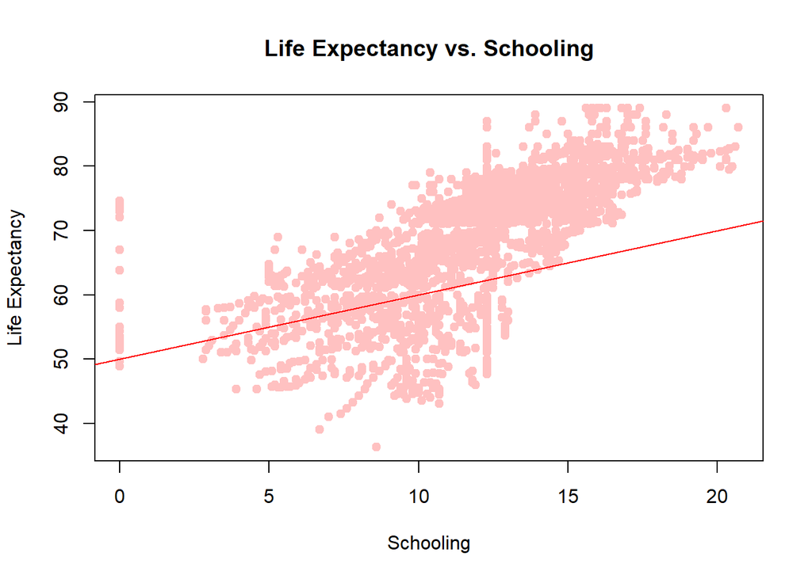

```r
plot(y = clean_data$Life.expectancy,
     x = clean_data$Schooling,
     main = "Life Expectancy vs. Schooling",
     xlab = "Schooling",
     ylab = "Life Expectancy",
     pch = 19,
     col = "rosybrown1")
abline(50,1,
       col = "red")      # 45 degree line (line with slope 1)
```

**Observation findings :**

1. The `Life.expectancy` and `Schooling` are positively correlated.
2. The red line in the plot indicates a correlation of 1 (45 degree line). Thus it is clear that the correlation is definitely less than 1.

#### Life Expectancy ~ Adult Mortality

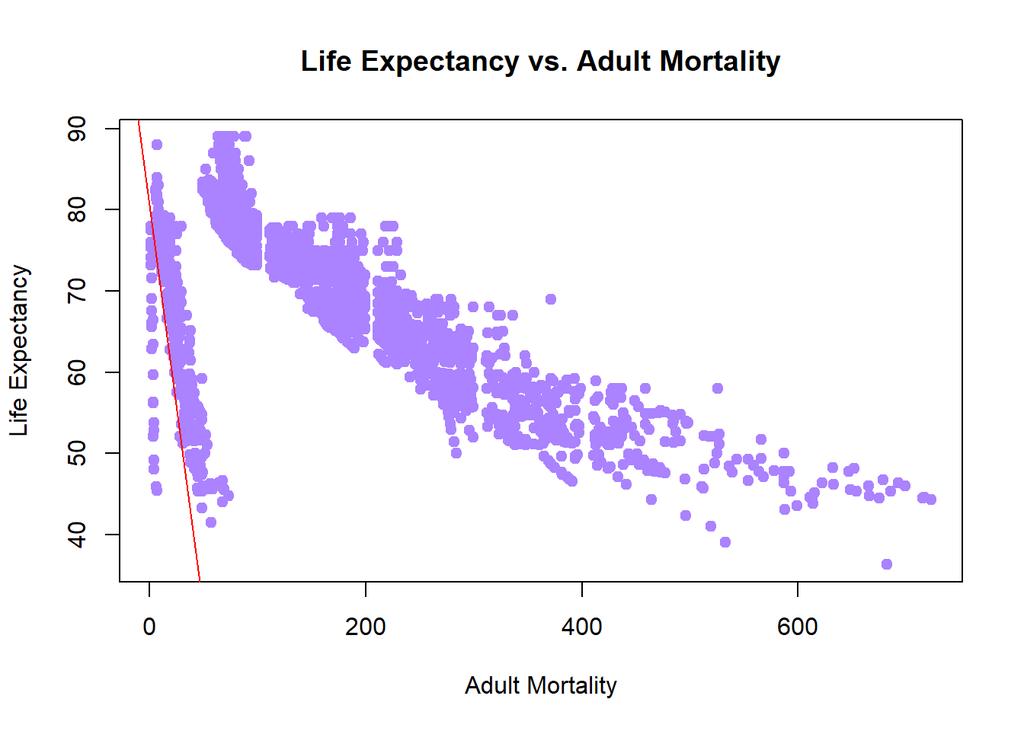

```r
plot(y = clean_data$Life.expectancy,
     x = clean_data$Adult.Mortality,
     main = "Life Expectancy vs. Adult Mortality",
     xlab = "Adult Mortality",
     ylab = "Life Expectancy",
     pch = 19,
     col = "mediumpurple1")
abline(80, - 1,
       col = "red")       # 135 degree line (line with slope -1)
```

**Observation findings :**

1. The `Life.expectancy` and `Adult.Mortality` are negatively correlated.
2. The red line in the plot indicates a correlation of -1 (135 degree line). Thus it is clear that the correlation is definitely not perfectly -1.

#### Life Expectancy ~ Population

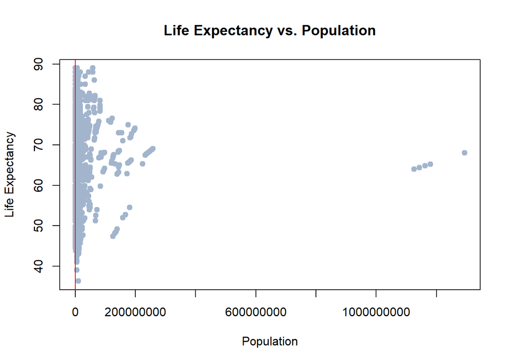

```r
plot(y = clean_data$Life.expectancy,
     x = clean_data$Population,
     main = "Life Expectancy vs. Population",
     xlab = "Population",
     ylab = "Life Expectancy",
     pch = 19,
     col = "lightsteelblue3")
abline(50,1,
       col = "red")      # 45 degree line (line with slope 1)
```

1. The `Life.expectancy` and `Population` are not really correlated.
2. The red line in the plot indicates a correlation of 1 (45 degree line). Thus it is clear that the correlation is negligible.

## Correlations

We need to check the linear relationship between the target variable and the predictor variables (independent variables).

Let’s find the correlations between the target variable `Life.expectancy` and first 5 predictors, i.e. `Adult.Morality`, `infant.deaths`, `Alcohol`, `percentage.expenditure`, and `Hepatitis.B`.

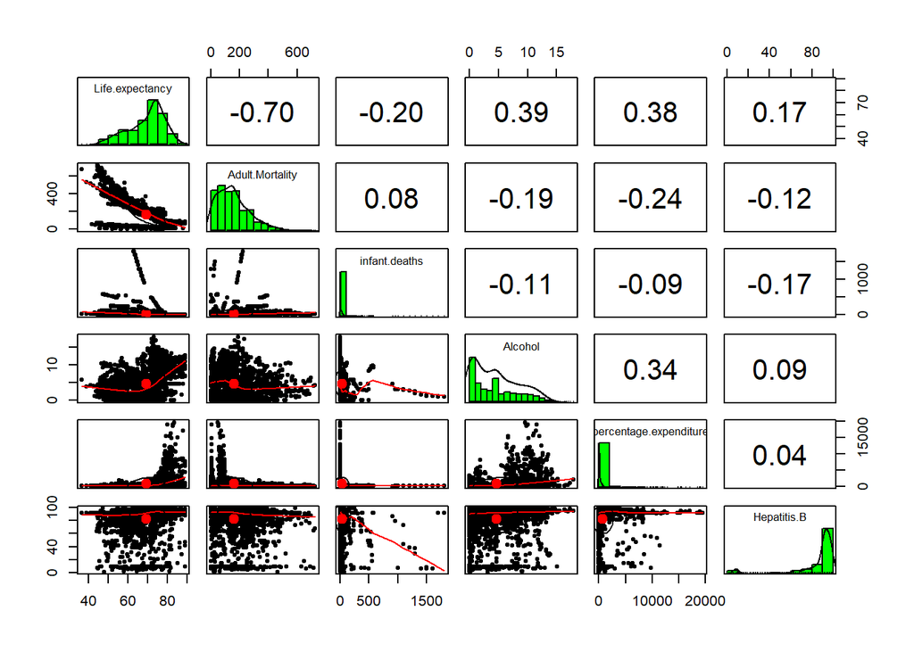

```r
# check correlations of the target variable with the first 5 predictors using Pearson correlation
pairs.panels(clean_data[,4:9],
             method = "pearson", # correlation method
             hist.col = "green",
             density = TRUE,  # show density plots
             ellipses = TRUE # show correlation ellipses
)
```

Next, let’s find the correlations between the target variable `Life.expectancy` and the next 5 predictors, i.e. `Measles`, `BMI`, `under.five.deaths`, `Polio`, and `Total.expenditure`.

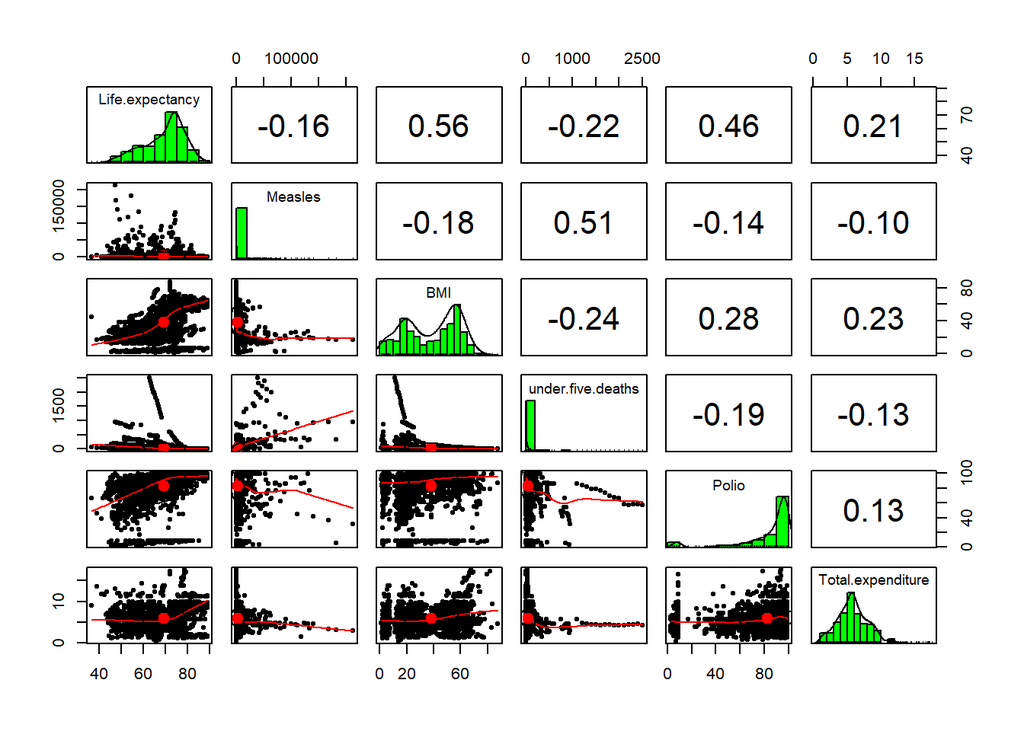

```r
# check correlations of the target variable with the next 5 predictors using Pearson correlation
pairs.panels(clean_data[,c(4,10:14)],
             method = "pearson", # correlation method
             hist.col = "green",
             density = TRUE,  # show density plots
             ellipses = TRUE # show correlation ellipses
)
```

Next, let’s find the correlations between the target variable `Life.expectancy` and the next 5 predictors, i.e. `Diphtheria`, `HIV.AIDS`, `GDP`, `Population`, and `thinness..1.19.years`.

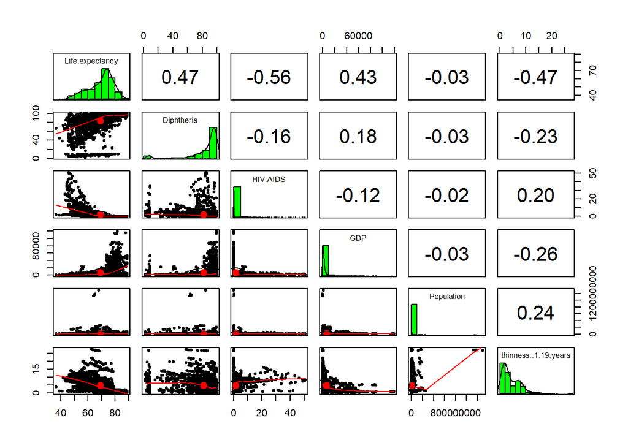

```r
# check correlations of the target variable with the next 5 predictors using Pearson correlation
pairs.panels(clean_data[,c(4,15:19)],
             method = "pearson", # correlation method
             hist.col = "green",
             density = TRUE,  # show density plots
             ellipses = TRUE # show correlation ellipses
)
```

Next, let’s find the correlations between the target variable `Life.expectancy` and the last 3 predictors, i.e. `thinness.5.9.years`, `Income.composition.of.resources`, and `Schooling`.

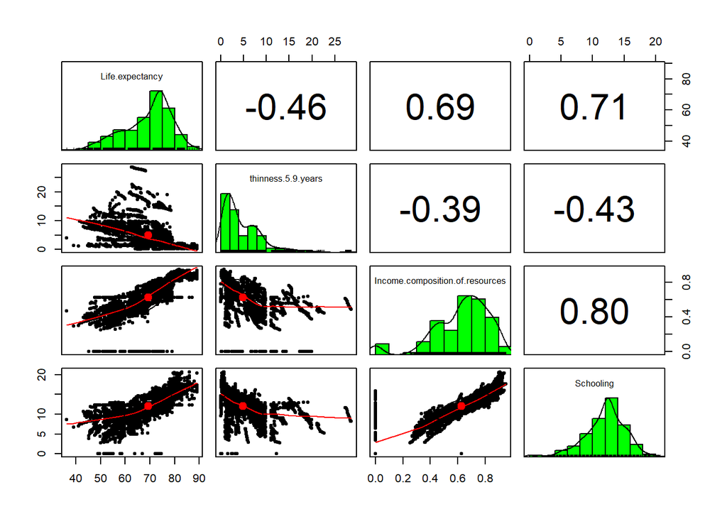

```r
# check correlations of the target variable with the last 3 predictors using Pearson correlation
pairs.panels(clean_data[,c(4,20:22)],
             method = "pearson", # correlation method
             hist.col = "green",
             density = TRUE,  # show density plots
             ellipses = TRUE # show correlation ellipses
)
```

According to Schober & Boer of the label interpretation of the r values, here are the labels of correlation based on the strength of the corresponding predictor:

1. Negligible correlation = 0.00 - 0.09
2. Weak correlation = 0.10 - 0.39
3. Moderate correlation = 0.40 - 0.69
4. Strong correlation = 0.70 - 0.89
5. Very strong correlation = 0.90 - 1.00

# **Modelling and Predicting**

Let’s make few models and predictions based on the dataset!

## Null Model

### Modelling

Let’s build a model without any predictors!

```r
# baseline model with no predictors
nullModel <- lm(Life.expectancy ~ 1,
                data = clean_data)

# check the model
summary(nullModel)
```

```
##
## Call:
## lm(formula = Life.expectancy ~ 1, data = clean_data)
##
## Residuals:
##     Min      1Q  Median      3Q     Max
## -32.935  -6.035   2.865   6.365  19.765
##
## Coefficients:
##             Estimate Std. Error t value            Pr(>|t|)
## (Intercept)  69.2347     0.1754   394.6 <0.0000000000000002 ***
## ---
## Signif. codes:  0 '***' 0.001 '**' 0.01 '*' 0.05 '.' 0.1 ' ' 1
##
## Residual standard error: 9.509 on 2937 degrees of freedom
```

### Predictions

The model is set! Let’s make a prediction based on the `nullModel`!

```r
nullModelPreds <- predict(nullModel,  # my model
                    newdata = clean_data, # dataset
                    type = "response") # to get predicted values
```

### Model Interpretation

Let’s interpreting the `nullModel`!

```r
summary (nullModel)
```

```
##
## Call:
## lm(formula = Life.expectancy ~ 1, data = clean_data)
##
## Residuals:
##     Min      1Q  Median      3Q     Max
## -32.935  -6.035   2.865   6.365  19.765
##
## Coefficients:
##             Estimate Std. Error t value            Pr(>|t|)
## (Intercept)  69.2347     0.1754   394.6 <0.0000000000000002 ***
## ---
## Signif. codes:  0 '***' 0.001 '**' 0.01 '*' 0.05 '.' 0.1 ' ' 1
##
## Residual standard error: 9.509 on 2937 degrees of freedom
```

**Observation findings :**

1. The `nullModel` has not any predictor.
2. If there is no predictor, then the `nullModel` will predict the future value using the mean value of the target variable or the `intercept` value.

## Full Model

### Modelling

Let’s build a model with all predictors, except `Country`!

```r
# baseline model with all predictors, except Country
fullModel <- lm(Life.expectancy ~ . - Country,
                data = clean_data)

# check the model
summary(fullModel)
```

```
##
## Call:
## lm(formula = Life.expectancy ~ . - Country, data = clean_data)
##
## Residuals:
##      Min       1Q   Median       3Q      Max
## -22.2860  -2.2437  -0.0817   2.3740  16.4282
##
## Coefficients:
##                                          Estimate        Std. Error t value
## (Intercept)                     81.57371776468257 34.65542497468053   2.354
## Year                            -0.01242470778379  0.01732564244728  -0.717
## StatusDeveloping                -1.60345349486797  0.27022829393151  -5.934
## Adult.Mortality                 -0.01981086120344  0.00079540789532 -24.907
## infant.deaths                    0.09932330190305  0.00842868251499  11.784
## Alcohol                          0.06135257680996  0.02608460875382   2.352
## percentage.expenditure           0.00003237640088  0.00009046842117   0.358
## Hepatitis.B                     -0.01660284006457  0.00371935046024  -4.464
## Measles                         -0.00001913469438  0.00000765428319  -2.500
## BMI                              0.04455147570409  0.00493230714916   9.033
## under.five.deaths               -0.07437771658324  0.00617691845324 -12.041
## Polio                            0.02865527021677  0.00444805095607   6.442
## Total.expenditure                0.07444995871406  0.03436772061263   2.166
## Diphtheria                       0.04078688657161  0.00464496059143   8.781
## HIV.AIDS                        -0.47215145572195  0.01764488354663 -26.759
## GDP                              0.00004260320835  0.00001378343058   3.091
## Population                       0.00000000001346  0.00000000168702   0.008
## thinness..1.19.years            -0.08195313416986  0.05028535403442  -1.630
## thinness.5.9.years               0.00847794195443  0.04956902498094   0.171
## Income.composition.of.resources  5.83669846548877  0.64052133954243   9.112
## Schooling                        0.64795815007715  0.04176733243002  15.514
##                                             Pr(>|t|)
## (Intercept)                                  0.01865 *
## Year                                         0.47335
## StatusDeveloping                      0.000000003311 ***
## Adult.Mortality                 < 0.0000000000000002 ***
## infant.deaths                   < 0.0000000000000002 ***
## Alcohol                                      0.01874 *
## percentage.expenditure                       0.72046
## Hepatitis.B                           0.000008352972 ***
## Measles                                      0.01248 *
## BMI                             < 0.0000000000000002 ***
## under.five.deaths               < 0.0000000000000002 ***
## Polio                                 0.000000000137 ***
## Total.expenditure                            0.03037 *
## Diphtheria                      < 0.0000000000000002 ***
## HIV.AIDS                        < 0.0000000000000002 ***
## GDP                                          0.00201 **
## Population                                   0.99364
## thinness..1.19.years                         0.10326
## thinness.5.9.years                           0.86421
## Income.composition.of.resources < 0.0000000000000002 ***
## Schooling                       < 0.0000000000000002 ***
## ---
## Signif. codes:  0 '***' 0.001 '**' 0.01 '*' 0.05 '.' 0.1 ' ' 1
##
## Residual standard error: 4.045 on 2917 degrees of freedom
## Multiple R-squared:  0.8203, Adjusted R-squared:  0.819
## F-statistic: 665.6 on 20 and 2917 DF,  p-value: < 0.00000000000000022
```

### Predictions

The model is set! Let’s make a prediction based on the `fullModel`!

```r
fullModelPreds <- predict(fullModel,  # my model
                    newdata = clean_data, # dataset
                    type = "response") # to get predicted values
```

### Model Interpretation

Let’s interpreting the `fullModel`!

```r
summary (fullModel)
```

```
##
## Call:
## lm(formula = Life.expectancy ~ . - Country, data = clean_data)
##
## Residuals:
##      Min       1Q   Median       3Q      Max
## -22.2860  -2.2437  -0.0817   2.3740  16.4282
##
## Coefficients:
##                                          Estimate        Std. Error t value
## (Intercept)                     81.57371776468257 34.65542497468053   2.354
## Year                            -0.01242470778379  0.01732564244728  -0.717
## StatusDeveloping                -1.60345349486797  0.27022829393151  -5.934
## Adult.Mortality                 -0.01981086120344  0.00079540789532 -24.907
## infant.deaths                    0.09932330190305  0.00842868251499  11.784
## Alcohol                          0.06135257680996  0.02608460875382   2.352
## percentage.expenditure           0.00003237640088  0.00009046842117   0.358
## Hepatitis.B                     -0.01660284006457  0.00371935046024  -4.464
## Measles                         -0.00001913469438  0.00000765428319  -2.500
## BMI                              0.04455147570409  0.00493230714916   9.033
## under.five.deaths               -0.07437771658324  0.00617691845324 -12.041
## Polio                            0.02865527021677  0.00444805095607   6.442
## Total.expenditure                0.07444995871406  0.03436772061263   2.166
## Diphtheria                       0.04078688657161  0.00464496059143   8.781
## HIV.AIDS                        -0.47215145572195  0.01764488354663 -26.759
## GDP                              0.00004260320835  0.00001378343058   3.091
## Population                       0.00000000001346  0.00000000168702   0.008
## thinness..1.19.years            -0.08195313416986  0.05028535403442  -1.630
## thinness.5.9.years               0.00847794195443  0.04956902498094   0.171
## Income.composition.of.resources  5.83669846548877  0.64052133954243   9.112
## Schooling                        0.64795815007715  0.04176733243002  15.514
##                                             Pr(>|t|)
## (Intercept)                                  0.01865 *
## Year                                         0.47335
## StatusDeveloping                      0.000000003311 ***
## Adult.Mortality                 < 0.0000000000000002 ***
## infant.deaths                   < 0.0000000000000002 ***
## Alcohol                                      0.01874 *
## percentage.expenditure                       0.72046
## Hepatitis.B                           0.000008352972 ***
## Measles                                      0.01248 *
## BMI                             < 0.0000000000000002 ***
## under.five.deaths               < 0.0000000000000002 ***
## Polio                                 0.000000000137 ***
## Total.expenditure                            0.03037 *
## Diphtheria                      < 0.0000000000000002 ***
## HIV.AIDS                        < 0.0000000000000002 ***
## GDP                                          0.00201 **
## Population                                   0.99364
## thinness..1.19.years                         0.10326
## thinness.5.9.years                           0.86421
## Income.composition.of.resources < 0.0000000000000002 ***
## Schooling                       < 0.0000000000000002 ***
## ---
## Signif. codes:  0 '***' 0.001 '**' 0.01 '*' 0.05 '.' 0.1 ' ' 1
##
## Residual standard error: 4.045 on 2917 degrees of freedom
## Multiple R-squared:  0.8203, Adjusted R-squared:  0.819
## F-statistic: 665.6 on 20 and 2917 DF,  p-value: < 0.00000000000000022
```

**Observation findings :**

1. The `fullModel` has the largest parameter estimate that is `Income.composition.of.resources` which is 5.836, followed by `StatusDeveloping` which is -1.60.
2. The `Income.composition.of.resources` will affect the `Life.expectancy` the most in a positive direction.
3. On the other hand, the `StatusDeveloping` will affect the `Life.expectancy` the most in a negative direction.
4. The p-value for `Adult.Mortality`, `infant.deaths`, `BMI`, `under.five.deaths`, `Diphtheria`, `HIV.AIDS`, `Income.composition.of.resources`, and `Schooling` are the least among all other predictors, thus indicating they are very significant predictors for `Life.expectancy`.
5. The `fullModel` has R-squared value 0.8203, which indicates the `fullModel` can describe its predictors condition by 82%.

### Actual vs. Predicted

#### Original Plot

Here is the Actual vs Predicted Plot of `fullModel`. The green line represents a perfect prediction, while the red line represents the regression line.

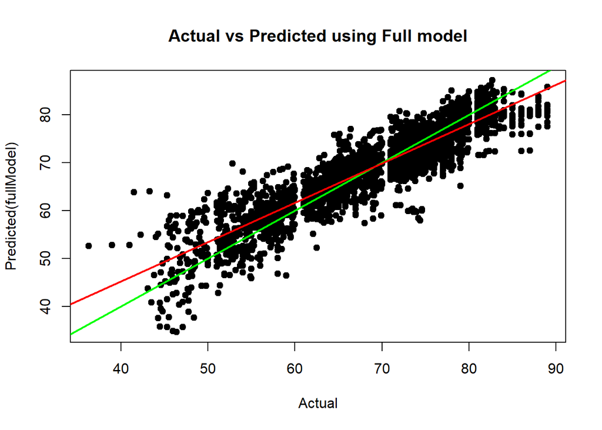

```r
# actual vs predicted
plot(y = fullModel$fitted.values,
     x = clean_data$Life.expectancy,
     main = "Actual vs Predicted using Full model",
     xlab = "Actual",
     ylab = "Predicted(fullModel)",
     pch = 19)
abline(0,1, col = "green", lwd = 2)  # this is a perfect prediction - 45 degree line

# add the regression line
abline(lm(fullModel$fitted.values ~ fullModel$model$Life.expectancy),
       col = "red", lwd = 2)
```

#### Plot with Confidence Interval (CI)

Here is the plot of the Actual vs Predicted of `fullModel` with Confidence Interval.

The blue line is the regression line, surrounding which in grey shade is the prediction interval. The confidence interval for the prediction is indicated by the dotted red line both above and below the regression line. The plot shows that almost all the data points lie well within the confidence interval of 95%.

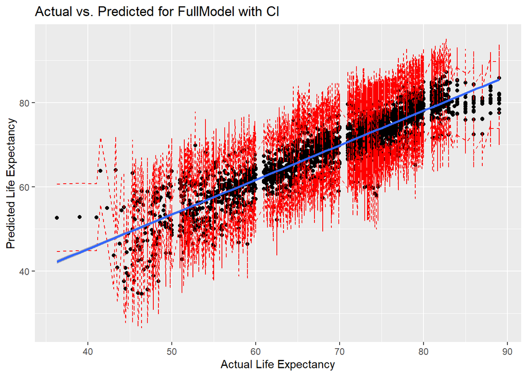

```r
# predict Life expectancy
predictedLE1 <- predict(fullModel, interval = "prediction")

# combine the actual data and predicted data
comb1 <- cbind.data.frame(clean_data, predictedLE1)

# Plotting the combined data
ggplot(comb1, aes(Life.expectancy, fit)) +
  geom_point() +
  geom_line(aes(y = lwr), color = "red", linetype = "dashed") +
  geom_line(aes(y = upr), color = "red", linetype = "dashed") +
  stat_smooth(method = lm) +
  geom_smooth(method=lm, se=TRUE)+
  ggtitle("Actual vs. Predicted for FullModel with CI") +
  xlab("Actual Life Expectancy") +
  ylab("Predicted Life Expectancy")
```

## EDA-Based Model

### Modelling

Let’s build a model with predictors that strongly correlated to target variable! The predictors are `Schooling`, `Adult.Mortality`, and `Income.composition.of.resources`.

```r
# baseline model with predictors that strongly correlated to target variable
EDAModel <- lm(Life.expectancy ~ Schooling +  Adult.Mortality + Income.composition.of.resources,
                data = clean_data)

# check the model
summary(EDAModel)
```

```
##
## Call:
## lm(formula = Life.expectancy ~ Schooling + Adult.Mortality +
##     Income.composition.of.resources, data = clean_data)
##
## Residuals:
##     Min      1Q  Median      3Q     Max
## -24.541  -1.933   0.374   2.619  23.151
##
## Coefficients:
##                                   Estimate Std. Error t value
## (Intercept)                     56.5263202  0.4782747  118.19
## Schooling                        0.9883753  0.0483207   20.45
## Adult.Mortality                 -0.0345377  0.0008571  -40.30
## Income.composition.of.resources 10.4014206  0.7731076   13.45
##                                            Pr(>|t|)
## (Intercept)                     <0.0000000000000002 ***
## Schooling                       <0.0000000000000002 ***
## Adult.Mortality                 <0.0000000000000002 ***
## Income.composition.of.resources <0.0000000000000002 ***
## ---
## Signif. codes:  0 '***' 0.001 '**' 0.01 '*' 0.05 '.' 0.1 ' ' 1
##
## Residual standard error: 5.114 on 2934 degrees of freedom
## Multiple R-squared:  0.711,  Adjusted R-squared:  0.7107
## F-statistic:  2406 on 3 and 2934 DF,  p-value: < 0.00000000000000022
```

### Predictions

The model is set! Let’s make a prediction based on the `EDAModel`!

```r
EDAModelPreds <- predict(EDAModel,  # my model
                    newdata = clean_data, # dataset
                    type = "response") # to get predicted values
```

### Model Interpretation

Let’s interpreting the `EDAModel`!

```r
summary (EDAModel)
```

```
##
## Call:
## lm(formula = Life.expectancy ~ Schooling + Adult.Mortality +
##     Income.composition.of.resources, data = clean_data)
##
## Residuals:
##     Min      1Q  Median      3Q     Max
## -24.541  -1.933   0.374   2.619  23.151
##
## Coefficients:
##                                   Estimate Std. Error t value
## (Intercept)                     56.5263202  0.4782747  118.19
## Schooling                        0.9883753  0.0483207   20.45
## Adult.Mortality                 -0.0345377  0.0008571  -40.30
## Income.composition.of.resources 10.4014206  0.7731076   13.45
##                                            Pr(>|t|)
## (Intercept)                     <0.0000000000000002 ***
## Schooling                       <0.0000000000000002 ***
## Adult.Mortality                 <0.0000000000000002 ***
## Income.composition.of.resources <0.0000000000000002 ***
## ---
## Signif. codes:  0 '***' 0.001 '**' 0.01 '*' 0.05 '.' 0.1 ' ' 1
##
## Residual standard error: 5.114 on 2934 degrees of freedom
## Multiple R-squared:  0.711,  Adjusted R-squared:  0.7107
## F-statistic:  2406 on 3 and 2934 DF,  p-value: < 0.00000000000000022
```

**Observation findings :**

1. The `EDAModel` has the largest parameter estimate that is `Income.composition.of.resources` which is 10.4.
2. The `Income.composition.of.resources` will affect the `Life.expectancy` the most in a positive direction.
3. The p-value of all predictors are much lower than 0.05, thus indicating they are very significant predictors for `Life.expectancy`.
4. The `EDAModel` has R-squared value 0.711, which indicates the `EDAModel` can describe its predictors condition by 71.1%.

### Actual vs. Predicted

#### Original Plot

Here is the Actual vs Predicted Plot of `EDAModel`. The green line represents a perfect prediction, while the red line represents the regression line.

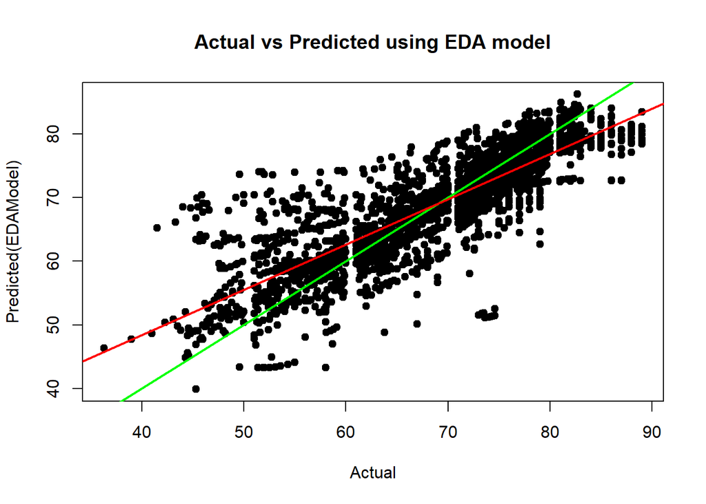

```r
# actual vs predicted
plot(y = EDAModel$fitted.values,
     x = clean_data$Life.expectancy,
     main = "Actual vs Predicted using EDA model",
     xlab = "Actual",
     ylab = "Predicted(EDAModel)",
     pch = 19)
abline(0,1, col = "green", lwd = 2)  # this is a perfect prediction - 45 degree line

# add the regression line
abline(lm(EDAModel$fitted.values ~ EDAModel$model$Life.expectancy),
       col = "red", lwd = 2)
```

#### Plot with Confidence Interval (CI)

Here is the plot of the Actual vs Predicted of `EDAModel` with Confidence Interval.

The blue line is the regression line, surrounding which in grey shade is the prediction interval. The confidence interval for the prediction is indicated by the dotted red line both above and below the regression line. The plot shows that almost all the data points lie well within the confidence interval of 95%.

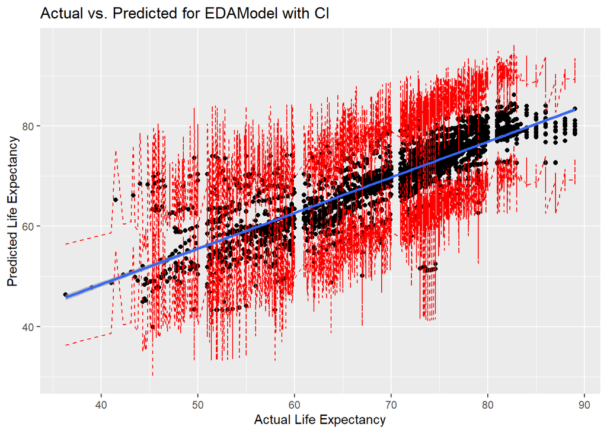

```r
# predict Life expectancy
predictedLE2 <- predict(EDAModel, interval = "prediction")

# combine the actual data and predicted data
comb2 <- cbind.data.frame(clean_data, predictedLE2)

# Plotting the combined data
ggplot(comb2, aes(Life.expectancy, fit)) +
  geom_point() +
  geom_line(aes(y = lwr), color = "red", linetype = "dashed") +
  geom_line(aes(y = upr), color = "red", linetype = "dashed") +
  stat_smooth(method = lm) +
  geom_smooth(method=lm, se=TRUE)+
  ggtitle("Actual vs. Predicted for EDAModel with CI") +
  xlab("Actual Life Expectancy") +
  ylab("Predicted Life Expectancy")
```

## Backward Step Model

### Modelling

Let’s build a model using step-wise regression with *backward* step!

The predictors of the `BackwardStepModel` are `Status`, `Adult.Mortality`, `infant.deaths`, `Alcohol`, `Hepatitis.B`, `Measles`, `BMI`, `under.five.deaths`, `Polio`, `Total.expenditure`, `Diphtheria`, `HIV.AIDS`, `GDP`, `thinness..1.19.years`, `Income.composition.of.resources`, and `Schooling`.

```r
BackwardStepModel <- step(fullModel,
                      direction = "backward")
```

```
## Start:  AIC=8232.93
## Life.expectancy ~ (Country + Year + Status + Adult.Mortality +
##     infant.deaths + Alcohol + percentage.expenditure + Hepatitis.B +
##     Measles + BMI + under.five.deaths + Polio + Total.expenditure +
##     Diphtheria + HIV.AIDS + GDP + Population + thinness..1.19.years +
##     thinness.5.9.years + Income.composition.of.resources + Schooling) -
##     Country
##
##                                   Df Sum of Sq   RSS    AIC
## - Population                       1       0.0 47735 8230.9
## - thinness.5.9.years               1       0.5 47735 8231.0
## - percentage.expenditure           1       2.1 47737 8231.1
## - Year                             1       8.4 47743 8231.4
## <none>                                         47735 8232.9
## - thinness..1.19.years             1      43.5 47778 8233.6
## - Total.expenditure                1      76.8 47811 8235.7
## - Alcohol                          1      90.5 47825 8236.5
## - Measles                          1     102.3 47837 8237.2
## - GDP                              1     156.3 47891 8240.5
## - Hepatitis.B                      1     326.1 48061 8250.9
## - Status                           1     576.2 48311 8266.2
## - Polio                            1     679.2 48414 8272.4
## - Diphtheria                       1    1261.8 48996 8307.6
## - BMI                              1    1335.1 49070 8312.0
## - Income.composition.of.resources  1    1358.8 49093 8313.4
## - infant.deaths                    1    2272.4 50007 8367.6
## - under.five.deaths                1    2372.7 50107 8373.5
## - Schooling                        1    3938.4 51673 8463.9
## - Adult.Mortality                  1   10151.4 57886 8797.4
## - HIV.AIDS                         1   11717.2 59452 8875.8
##
## Step:  AIC=8230.93
## Life.expectancy ~ Year + Status + Adult.Mortality + infant.deaths +
##     Alcohol + percentage.expenditure + Hepatitis.B + Measles +
##     BMI + under.five.deaths + Polio + Total.expenditure + Diphtheria +
##     HIV.AIDS + GDP + thinness..1.19.years + thinness.5.9.years +
##     Income.composition.of.resources + Schooling
##
##                                   Df Sum of Sq   RSS    AIC
## - thinness.5.9.years               1       0.5 47735 8229.0
```

[output cut: 85 more lines]

```
## - Measles                          1     100.0 47847 8229.8
## - Alcohol                          1     103.5 47850 8230.0
## - thinness..1.19.years             1     162.3 47909 8233.6
## - Hepatitis.B                      1     329.1 48076 8243.8
## - Status                           1     598.8 48345 8260.3
## - Polio                            1     680.9 48428 8265.3
## - GDP                              1     814.2 48561 8273.3
## - Diphtheria                       1    1257.0 49004 8300.0
## - BMI                              1    1348.5 49095 8305.5
## - Income.composition.of.resources  1    1352.2 49099 8305.7
## - infant.deaths                    1    2373.7 50120 8366.2
## - under.five.deaths                1    2435.4 50182 8369.8
## - Schooling                        1    3937.5 51684 8456.5
## - Adult.Mortality                  1   10266.6 58013 8795.9
## - HIV.AIDS                         1   11809.6 59556 8873.0
```

### Predictions

The model is set! Let’s make a prediction based on the `BackwardStepModel`!

```r
BackwardStepModelPreds <- predict(BackwardStepModel,  # my model
                    newdata = clean_data, # dataset
                    type = "response") # to get predicted values
```

### Model Interpretation

Let’s interpreting the `BackwardStepModel`!

```r
summary (BackwardStepModel)
```

```
##
## Call:
## lm(formula = Life.expectancy ~ Status + Adult.Mortality + infant.deaths +
##     Alcohol + Hepatitis.B + Measles + BMI + under.five.deaths +
##     Polio + Total.expenditure + Diphtheria + HIV.AIDS + GDP +
##     thinness..1.19.years + Income.composition.of.resources +
##     Schooling, data = clean_data)
##
## Residuals:
##      Min       1Q   Median       3Q      Max
## -22.2503  -2.2438  -0.1097   2.3665  16.3824
##
## Coefficients:
##                                     Estimate   Std. Error t value
## (Intercept)                     56.745781830  0.668314373  84.909
## StatusDeveloping                -1.625002116  0.268478794  -6.053
## Adult.Mortality                 -0.019850253  0.000792059 -25.062
## infant.deaths                    0.099679379  0.008271756  12.051
## Alcohol                          0.064726322  0.025725807   2.516
## Hepatitis.B                     -0.016610250  0.003701821  -4.487
## Measles                         -0.000018876  0.000007631  -2.474
## BMI                              0.044354554  0.004883370   9.083
## under.five.deaths               -0.074629707  0.006114028 -12.206
## Polio                            0.028664684  0.004441145   6.454
## Total.expenditure                0.073561760  0.033733716   2.181
## Diphtheria                       0.040593295  0.004629077   8.769
## HIV.AIDS                        -0.470653224  0.017510073 -26.879
## GDP                              0.000046752  0.000006624   7.058
## thinness..1.19.years            -0.074951946  0.023787239  -3.151
## Income.composition.of.resources  5.762655777  0.633592391   9.095
## Schooling                        0.645416268  0.041585022  15.520
##                                             Pr(>|t|)
## (Intercept)                     < 0.0000000000000002 ***
## StatusDeveloping                    0.00000000160683 ***
## Adult.Mortality                 < 0.0000000000000002 ***
## infant.deaths                   < 0.0000000000000002 ***
## Alcohol                                      0.01192 *
## Hepatitis.B                         0.00000750069921 ***
## Measles                                      0.01343 *
## BMI                             < 0.0000000000000002 ***
## under.five.deaths               < 0.0000000000000002 ***
## Polio                               0.00000000012680 ***
## Total.expenditure                            0.02929 *
## Diphtheria                      < 0.0000000000000002 ***
## HIV.AIDS                        < 0.0000000000000002 ***
## GDP                                 0.00000000000211 ***
## thinness..1.19.years                         0.00164 **
## Income.composition.of.resources < 0.0000000000000002 ***
## Schooling                       < 0.0000000000000002 ***
## ---
## Signif. codes:  0 '***' 0.001 '**' 0.01 '*' 0.05 '.' 0.1 ' ' 1
##
## Residual standard error: 4.043 on 2921 degrees of freedom
## Multiple R-squared:  0.8202, Adjusted R-squared:  0.8192
## F-statistic: 832.9 on 16 and 2921 DF,  p-value: < 0.00000000000000022
```

**Observation findings :**

1. The `BackwardStepModel` has the largest parameter estimate that is `Income.composition.of.resources` which is 5.762, followed by `StatusDeveloping` which is -1.625.
2. The `Income.composition.of.resources` will affect the `Life.expectancy` the most in a positive direction.
3. On the other hand, the `StatusDeveloping` will affect the `Life.expectancy` the most in a negative direction.
4. The p-value for its `intercept`, `Adult.Mortality`, `infant.deaths`, `BMI`, `under.five.deaths`, `Diphtheria`, `HIV.AIDS`, `Income.composition.of.resources`, and `Schooling` are the least among all other predictors, thus indicating they are very significant predictors for `Life.expectancy`.
5. The `BackwardStepModel` has R-squared value 0.8202, which indicates the `BackwardStepModel` can describe its predictors condition by 82%.

### Actual vs. Predicted

#### Original Plot

Here is the Actual vs Predicted Plot of `BackwardStepModel`. The green line represents a perfect prediction, while the red line represents the regression line.

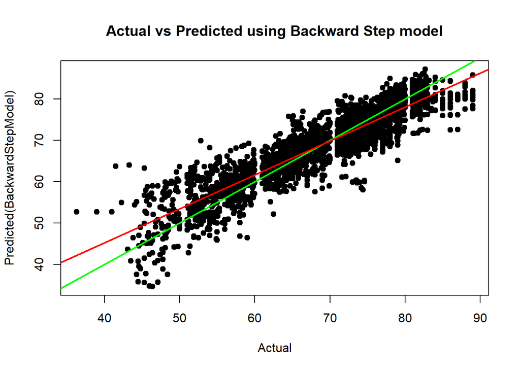

```r
# actual vs predicted
plot(y = BackwardStepModel$fitted.values,
     x = clean_data$Life.expectancy,
     main = "Actual vs Predicted using Backward Step model",
     xlab = "Actual",
     ylab = "Predicted(BackwardStepModel)",
     pch = 19)
abline(0,1, col = "green", lwd = 2)  # this is a perfect prediction - 45 degree line

# add the regression line
abline(lm(BackwardStepModel$fitted.values ~ BackwardStepModel$model$Life.expectancy),
       col = "red", lwd = 2)
```

#### Plot with Confidence Interval (CI)

Here is the plot of the Actual vs Predicted of `BackwardStepModel` with Confidence Interval.

The blue line is the regression line, surrounding which in grey shade is the prediction interval. The confidence interval for the prediction is indicated by the dotted red line both above and below the regression line. The plot shows that almost all the data points lie well within the confidence interval of 95%.

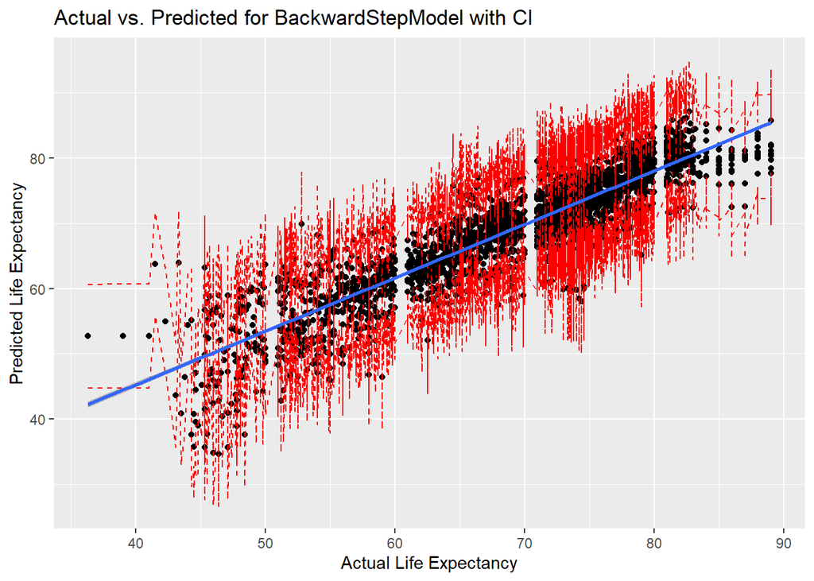

```r
# predict Life expectancy
predictedLE3 <- predict(BackwardStepModel, interval = "prediction")

# combine the actual data and predicted data
comb3 <- cbind.data.frame(clean_data, predictedLE3)

# Plotting the combined data
ggplot(comb3, aes(Life.expectancy, fit)) +
  geom_point() +
  geom_line(aes(y = lwr), color = "red", linetype = "dashed") +
  geom_line(aes(y = upr), color = "red", linetype = "dashed") +
  stat_smooth(method = lm) +
  geom_smooth(method=lm, se=TRUE)+
  ggtitle("Actual vs. Predicted for BackwardStepModel with CI") +
  xlab("Actual Life Expectancy") +
  ylab("Predicted Life Expectancy")
```

## Forward Step Model

### Modelling

Let’s build a model using step-wise regression with *forward* step!

The predictors of the `forwardStepModel` are `Schooling`, `Adult.Mortality`, `HIV.AIDS`, `Diphtheria`, `BMI`, `Income.composition.of.resources`, `Status`, `Polio`, `GDP`, `Hepatitis.B`, `under.five.deaths`, `infant.deaths`, `thinness..1.19.years`, `Alcohol`, `Measles`, and `Total.expenditure`.

```r
forwardStepModel <- step(nullModel,
                         direction="forward",
                         scope=list(lower=nullModel,
                                    upper=fullModel))
```

```
## Start:  AIC=13235.23
## Life.expectancy ~ 1
##
##                                   Df Sum of Sq    RSS   AIC
## + Schooling                        1    135029 130544 11151
## + Adult.Mortality                  1    128792 136781 11288
## + Income.composition.of.resources  1    127379 138194 11318
## + BMI                              1     83419 182155 12130
## + HIV.AIDS                         1     82306 183267 12147
## + Status                           1     61549 204024 12463
## + Diphtheria                       1     59218 206355 12496
## + thinness..1.19.years             1     58167 207406 12511
## + thinness.5.9.years               1     56801 208772 12530
## + Polio                            1     55805 209768 12544
## + GDP                              1     49210 216363 12635
## + Alcohol                          1     40534 225039 12751
## + percentage.expenditure           1     38636 226938 12775
## + under.five.deaths                1     13176 252397 13088
## + Total.expenditure                1     11583 253990 13106
## + infant.deaths                    1     10282 255291 13121
## + Year                             1      7749 257824 13150
## + Hepatitis.B                      1      7695 257878 13151
## + Measles                          1      6610 258963 13163
## + Population                       1       224 265350 13235
## <none>                                         265573 13235
##
## Step:  AIC=11150.71
## Life.expectancy ~ Schooling
##
##                                   Df Sum of Sq    RSS     AIC
## + Adult.Mortality                  1     49061  81483  9768.0
## + HIV.AIDS                         1     44779  85765  9918.5
## + BMI                              1     14155 116389 10815.5
## + Diphtheria                       1     12645 117899 10853.4
## + Income.composition.of.resources  1     11318 119225 10886.3
## + Polio                            1     11213 119331 10888.9
## + thinness.5.9.years               1      8113 122431 10964.2
## + thinness..1.19.years             1      8021 122523 10966.4
## + Status                           1      5919 124625 11016.4
## + GDP                              1      4882 125662 11040.7
```

[output cut: 273 more lines]

```
## + thinness.5.9.years      1     0.085 47824 8230.4
## + Population              1     0.023 47824 8230.4
##
## Step:  AIC=8225.67
## Life.expectancy ~ Schooling + Adult.Mortality + HIV.AIDS + Diphtheria +
##     BMI + Income.composition.of.resources + Status + Polio +
##     GDP + Hepatitis.B + under.five.deaths + infant.deaths + thinness..1.19.years +
##     Alcohol + Measles + Total.expenditure
##
##                          Df Sum of Sq   RSS    AIC
## <none>                                47747 8225.7
## + Year                    1    9.3541 47737 8227.1
## + percentage.expenditure  1    3.0234 47744 8227.5
## + thinness.5.9.years      1    0.5265 47746 8227.6
## + Population              1    0.0011 47747 8227.7
```

### Predictions

The model is set! Let’s make a prediction based on the `forwardStepModel`!

```r
forwardStepModelPreds <- predict(forwardStepModel,  # my model
                    newdata = clean_data, # dataset
                    type = "response") # to get predicted values
```

### Model Interpretation

Let’s interpreting the `forwardStepModel`!

```r
summary (forwardStepModel)
```

```
##
## Call:
## lm(formula = Life.expectancy ~ Schooling + Adult.Mortality +
##     HIV.AIDS + Diphtheria + BMI + Income.composition.of.resources +
##     Status + Polio + GDP + Hepatitis.B + under.five.deaths +
##     infant.deaths + thinness..1.19.years + Alcohol + Measles +
##     Total.expenditure, data = clean_data)
##
## Residuals:
##      Min       1Q   Median       3Q      Max
## -22.2503  -2.2438  -0.1097   2.3665  16.3824
##
## Coefficients:
##                                     Estimate   Std. Error t value
## (Intercept)                     56.745781830  0.668314373  84.909
## Schooling                        0.645416268  0.041585022  15.520
## Adult.Mortality                 -0.019850253  0.000792059 -25.062
## HIV.AIDS                        -0.470653224  0.017510073 -26.879
## Diphtheria                       0.040593295  0.004629077   8.769
## BMI                              0.044354554  0.004883370   9.083
## Income.composition.of.resources  5.762655777  0.633592391   9.095
## StatusDeveloping                -1.625002116  0.268478794  -6.053
## Polio                            0.028664684  0.004441145   6.454
## GDP                              0.000046752  0.000006624   7.058
## Hepatitis.B                     -0.016610250  0.003701821  -4.487
## under.five.deaths               -0.074629707  0.006114028 -12.206
## infant.deaths                    0.099679379  0.008271756  12.051
## thinness..1.19.years            -0.074951946  0.023787239  -3.151
## Alcohol                          0.064726322  0.025725807   2.516
## Measles                         -0.000018876  0.000007631  -2.474
## Total.expenditure                0.073561760  0.033733716   2.181
##                                             Pr(>|t|)
## (Intercept)                     < 0.0000000000000002 ***
## Schooling                       < 0.0000000000000002 ***
## Adult.Mortality                 < 0.0000000000000002 ***
## HIV.AIDS                        < 0.0000000000000002 ***
## Diphtheria                      < 0.0000000000000002 ***
## BMI                             < 0.0000000000000002 ***
## Income.composition.of.resources < 0.0000000000000002 ***
## StatusDeveloping                    0.00000000160683 ***
## Polio                               0.00000000012680 ***
## GDP                                 0.00000000000211 ***
## Hepatitis.B                         0.00000750069921 ***
## under.five.deaths               < 0.0000000000000002 ***
## infant.deaths                   < 0.0000000000000002 ***
## thinness..1.19.years                         0.00164 **
## Alcohol                                      0.01192 *
## Measles                                      0.01343 *
## Total.expenditure                            0.02929 *
## ---
## Signif. codes:  0 '***' 0.001 '**' 0.01 '*' 0.05 '.' 0.1 ' ' 1
##
## Residual standard error: 4.043 on 2921 degrees of freedom
## Multiple R-squared:  0.8202, Adjusted R-squared:  0.8192
## F-statistic: 832.9 on 16 and 2921 DF,  p-value: < 0.00000000000000022
```

**Observation findings :**

1. The `forwardStepModel` has the largest parameter estimate that is `Income.composition.of.resources` which is 5.762, followed by `StatusDeveloping` which is -1.625.
2. The `Income.composition.of.resources` will affect the `Life.expectancy` the most in a positive direction.
3. On the other hand, the `StatusDeveloping` will affect the `Life.expectancy` the most in a negative direction.
4. The p-value for its `intercept`, `Schooling`, `Adult.Mortality`, `HIV.AIDS`, `Diphtheria`, `BMI`, `Income.composition.of.resources`, `under.five.deaths`, and `infant.deaths` are the least among all other predictors, thus indicating they are very significant predictors for `Life.expectancy`.
5. The `forwardStepModel` has R-squared value 0.8202, which indicates the `forwardStepModel` can describe its predictors condition by 82%.

### Actual vs. Predicted

#### Original Plot

Here is the Actual vs Predicted Plot of `forwardStepModel`. The green line represents a perfect prediction, while the red line represents the regression line.

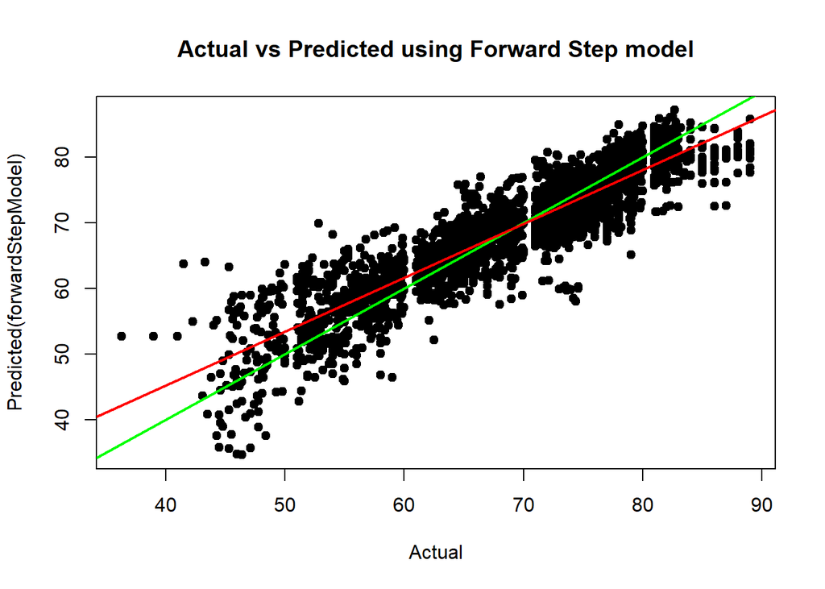

```r
# actual vs predicted
plot(y = forwardStepModel$fitted.values,
     x = clean_data$Life.expectancy,
     main = "Actual vs Predicted using Forward Step model",
     xlab = "Actual",
     ylab = "Predicted(forwardStepModel)",
     pch = 19)

abline(0,1, col = "green", lwd = 2)  # this is a perfect prediction - 45 degree line

# add the regression line
abline(lm(forwardStepModel$fitted.values ~ forwardStepModel$model$Life.expectancy),
       col = "red", lwd = 2)
```

#### Plot with Confidence Interval (CI)

Here is the plot of the Actual vs Predicted of `forwardStepModel` with Confidence Interval.

The blue line is the regression line, surrounding which in grey shade is the prediction interval. The confidence interval for the prediction is indicated by the dotted red line both above and below the regression line. The plot shows that almost all the data points lie well within the confidence interval of 95%.

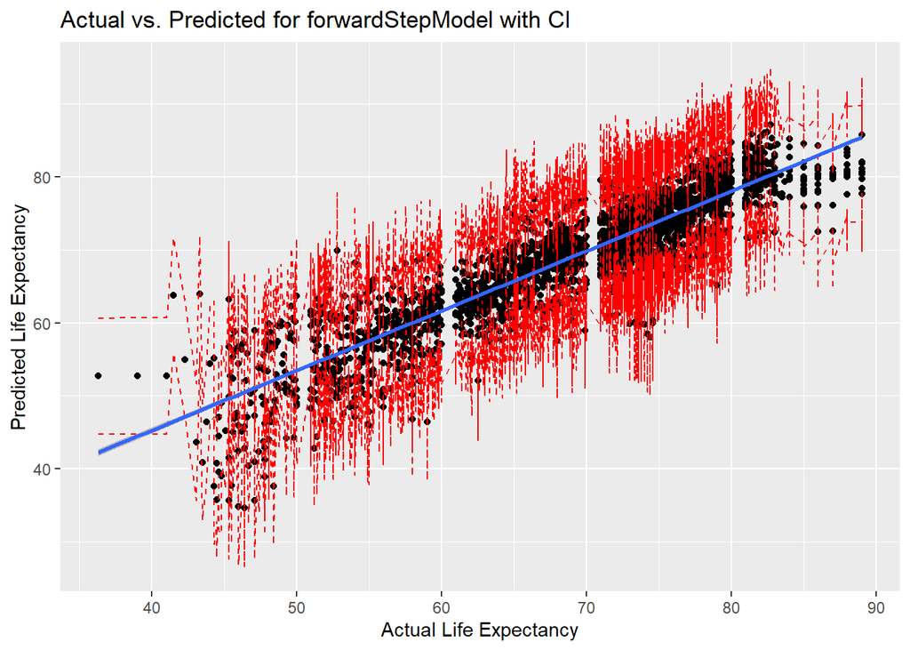

```r
# predict Life expectancy
predictedLE4 <- predict(forwardStepModel, interval = "prediction")

# combine the actual data and predicted data
comb4 <- cbind.data.frame(clean_data, predictedLE4)

# Plotting the combined data
ggplot(comb4, aes(Life.expectancy, fit)) +
  geom_point() +
  geom_line(aes(y = lwr), color = "red", linetype = "dashed") +
  geom_line(aes(y = upr), color = "red", linetype = "dashed") +
  stat_smooth(method = lm) +
  geom_smooth(method=lm, se=TRUE)+
  ggtitle("Actual vs. Predicted for forwardStepModel with CI") +
  xlab("Actual Life Expectancy") +
  ylab("Predicted Life Expectancy")
```

## Mixed Step Model

### Modelling

Let’s build a model using step-wise regression with both *backward* and *forward* step!

The predictors of the `MixedStepModel` are `Schooling`, `Adult.Mortality`, `HIV.AIDS`, `Diphtheria`, `BMI`, `Income.composition.of.resources`, `Status`, `Polio`, `GDP`, `Hepatitis.B`, `under.five.deaths`, `infant.deaths`, `thinness..1.19.years`, `Alcohol`, `Measles`, and `Total.expenditure`.

```r
MixedStepModel <- step(nullModel,
                         scope=list(lower=nullModel,
                                    upper=fullModel),
                         direction="both")
```

```
## Start:  AIC=13235.23
## Life.expectancy ~ 1
##
##                                   Df Sum of Sq    RSS   AIC
## + Schooling                        1    135029 130544 11151
## + Adult.Mortality                  1    128792 136781 11288
## + Income.composition.of.resources  1    127379 138194 11318
## + BMI                              1     83419 182155 12130
## + HIV.AIDS                         1     82306 183267 12147
## + Status                           1     61549 204024 12463
## + Diphtheria                       1     59218 206355 12496
## + thinness..1.19.years             1     58167 207406 12511
## + thinness.5.9.years               1     56801 208772 12530
## + Polio                            1     55805 209768 12544
## + GDP                              1     49210 216363 12635
## + Alcohol                          1     40534 225039 12751
## + percentage.expenditure           1     38636 226938 12775
## + under.five.deaths                1     13176 252397 13088
## + Total.expenditure                1     11583 253990 13106
## + infant.deaths                    1     10282 255291 13121
## + Year                             1      7749 257824 13150
## + Hepatitis.B                      1      7695 257878 13151
## + Measles                          1      6610 258963 13163
## + Population                       1       224 265350 13235
## <none>                                         265573 13235
##
## Step:  AIC=11150.71
## Life.expectancy ~ Schooling
##
##                                   Df Sum of Sq    RSS     AIC
## + Adult.Mortality                  1     49061  81483  9768.0
## + HIV.AIDS                         1     44779  85765  9918.5
## + BMI                              1     14155 116389 10815.5
## + Diphtheria                       1     12645 117899 10853.4
## + Income.composition.of.resources  1     11318 119225 10886.3
## + Polio                            1     11213 119331 10888.9
## + thinness.5.9.years               1      8113 122431 10964.2
## + thinness..1.19.years             1      8021 122523 10966.4
## + Status                           1      5919 124625 11016.4
## + GDP                              1      4882 125662 11040.7
```

[output cut: 409 more lines]

```
## - Measles                          1     100.0 47847 8229.8
## - Alcohol                          1     103.5 47850 8230.0
## - thinness..1.19.years             1     162.3 47909 8233.6
## - Hepatitis.B                      1     329.1 48076 8243.8
## - Status                           1     598.8 48345 8260.3
## - Polio                            1     680.9 48428 8265.3
## - GDP                              1     814.2 48561 8273.3
## - Diphtheria                       1    1257.0 49004 8300.0
## - BMI                              1    1348.5 49095 8305.5
## - Income.composition.of.resources  1    1352.2 49099 8305.7
## - infant.deaths                    1    2373.7 50120 8366.2
## - under.five.deaths                1    2435.4 50182 8369.8
## - Schooling                        1    3937.5 51684 8456.5
## - Adult.Mortality                  1   10266.6 58013 8795.9
## - HIV.AIDS                         1   11809.6 59556 8873.0
```

### Predictions

The model is set! Let’s make a prediction based on the `MixedStepModel`!

```r
MixedStepModelPreds <- predict(MixedStepModel,  # my model
                    newdata = clean_data, # dataset
                    type = "response") # to get predicted values
```

### Model Interpretation

Let’s interpreting the `MixedStepModel`!

```r
summary (MixedStepModel)
```

```
##
## Call:
## lm(formula = Life.expectancy ~ Schooling + Adult.Mortality +
##     HIV.AIDS + Diphtheria + BMI + Income.composition.of.resources +
##     Status + Polio + GDP + Hepatitis.B + under.five.deaths +
##     infant.deaths + thinness..1.19.years + Alcohol + Measles +
##     Total.expenditure, data = clean_data)
##
## Residuals:
##      Min       1Q   Median       3Q      Max
## -22.2503  -2.2438  -0.1097   2.3665  16.3824
##
## Coefficients:
##                                     Estimate   Std. Error t value
## (Intercept)                     56.745781830  0.668314373  84.909
## Schooling                        0.645416268  0.041585022  15.520
## Adult.Mortality                 -0.019850253  0.000792059 -25.062
## HIV.AIDS                        -0.470653224  0.017510073 -26.879
## Diphtheria                       0.040593295  0.004629077   8.769
## BMI                              0.044354554  0.004883370   9.083
## Income.composition.of.resources  5.762655777  0.633592391   9.095
## StatusDeveloping                -1.625002116  0.268478794  -6.053
## Polio                            0.028664684  0.004441145   6.454
## GDP                              0.000046752  0.000006624   7.058
## Hepatitis.B                     -0.016610250  0.003701821  -4.487
## under.five.deaths               -0.074629707  0.006114028 -12.206
## infant.deaths                    0.099679379  0.008271756  12.051
## thinness..1.19.years            -0.074951946  0.023787239  -3.151
## Alcohol                          0.064726322  0.025725807   2.516
## Measles                         -0.000018876  0.000007631  -2.474
## Total.expenditure                0.073561760  0.033733716   2.181
##                                             Pr(>|t|)
## (Intercept)                     < 0.0000000000000002 ***
## Schooling                       < 0.0000000000000002 ***
## Adult.Mortality                 < 0.0000000000000002 ***
## HIV.AIDS                        < 0.0000000000000002 ***
## Diphtheria                      < 0.0000000000000002 ***
## BMI                             < 0.0000000000000002 ***
## Income.composition.of.resources < 0.0000000000000002 ***
## StatusDeveloping                    0.00000000160683 ***
## Polio                               0.00000000012680 ***
## GDP                                 0.00000000000211 ***
## Hepatitis.B                         0.00000750069921 ***
## under.five.deaths               < 0.0000000000000002 ***
## infant.deaths                   < 0.0000000000000002 ***
## thinness..1.19.years                         0.00164 **
## Alcohol                                      0.01192 *
## Measles                                      0.01343 *
## Total.expenditure                            0.02929 *
## ---
## Signif. codes:  0 '***' 0.001 '**' 0.01 '*' 0.05 '.' 0.1 ' ' 1
##
## Residual standard error: 4.043 on 2921 degrees of freedom
## Multiple R-squared:  0.8202, Adjusted R-squared:  0.8192
## F-statistic: 832.9 on 16 and 2921 DF,  p-value: < 0.00000000000000022
```

**Observation findings :**

1. The `MixedStepModel` has the largest parameter estimate that is `Income.composition.of.resources` which is 5.762, followed by `StatusDeveloping` which is -1.625.
2. The `Income.composition.of.resources` will affect the `Life.expectancy` the most in a positive direction.
3. On the other hand, the `StatusDeveloping` will affect the `Life.expectancy` the most in a negative direction.
4. The p-value for its `intercept`, `Schooling`, `Adult.Mortality`, `HIV.AIDS`, `Diphtheria`, `BMI`, `Income.composition.of.resources`, `under.five.deaths`, and `infant.deaths` are the least among all other predictors, thus indicating they are very significant predictors for `Life.expectancy`.
5. The `MixedStepModel` has R-squared value 0.8202, which indicates the `MixedStepModel` can describe its predictors condition by 82%.

### Actual vs. Predicted

#### Original Plot

Here is the Actual vs Predicted Plot of `MixedStepModel`. The green line represents a perfect prediction, while the red line represents the regression line.

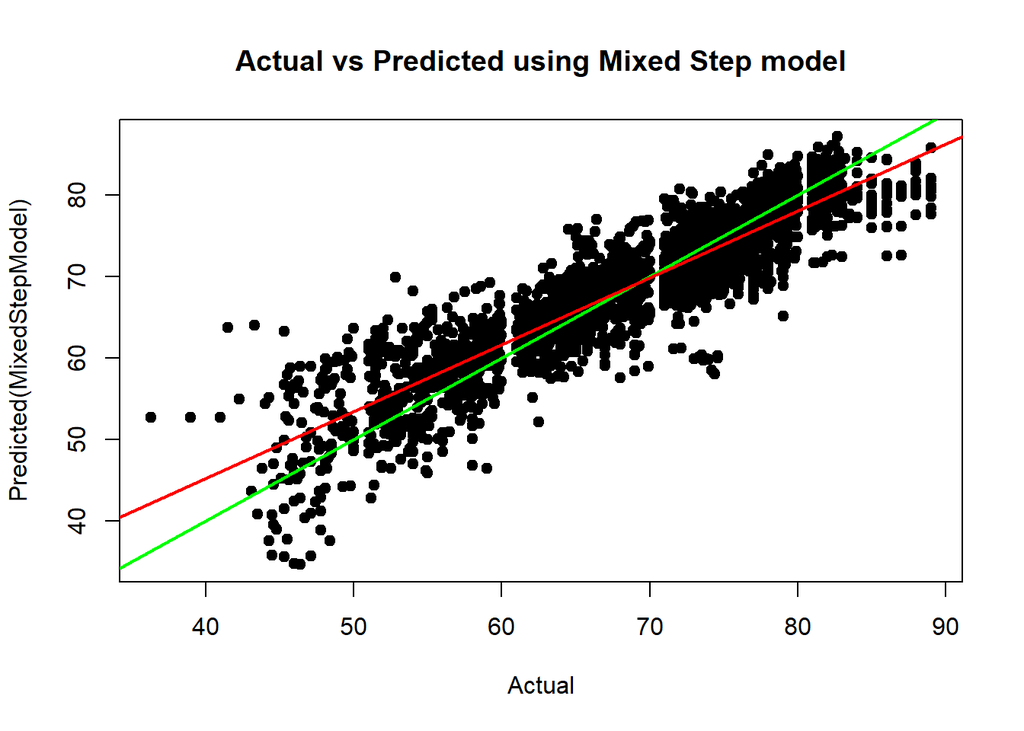

```r
# actual vs predicted
plot(y = MixedStepModel$fitted.values,
     x = clean_data$Life.expectancy,
     main = "Actual vs Predicted using Mixed Step model",
     xlab = "Actual",
     ylab = "Predicted(MixedStepModel)",
     pch = 19)
abline(0,1, col = "green", lwd = 2)  # this is a perfect prediction - 45 degree line

# add the regression line
abline(lm(MixedStepModel$fitted.values ~ MixedStepModel$model$Life.expectancy),
       col = "red", lwd = 2)
```

#### Plot with Confidence Interval (CI)

Here is the plot of the Actual vs Predicted of `MixedStepModel` with Confidence Interval.

The blue line is the regression line, surrounding which in grey shade is the prediction interval. The confidence interval for the prediction is indicated by the dotted red line both above and below the regression line. The plot shows that almost all the data points lie well within the confidence interval of 95%.

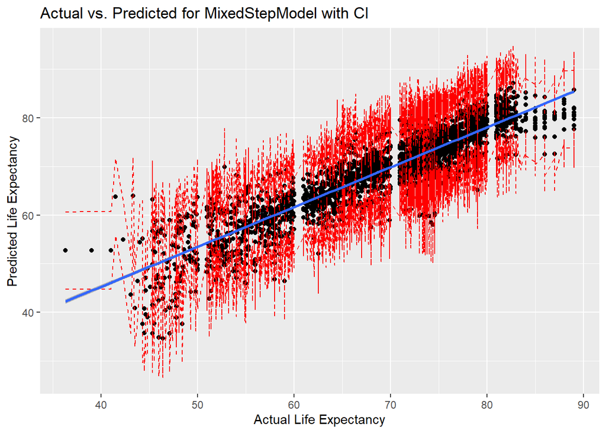

```r
# predict Life expectancy
predictedLE5 <- predict(MixedStepModel, interval = "prediction")

# combine the actual data and predicted data
comb5 <- cbind.data.frame(clean_data, predictedLE5)

# Plotting the combined data
ggplot(comb5, aes(Life.expectancy, fit)) +
  geom_point() +
  geom_line(aes(y = lwr), color = "red", linetype = "dashed") +
  geom_line(aes(y = upr), color = "red", linetype = "dashed") +
  stat_smooth(method = lm) +
  geom_smooth(method=lm, se=TRUE)+
  ggtitle("Actual vs. Predicted for MixedStepModel with CI") +
  xlab("Actual Life Expectancy") +
  ylab("Predicted Life Expectancy")
```

## Fitting Reduced model using VIF

### Modelling

The `fitModel` is a `fullModel` with predictors that have VIF (Variable Inflation Factors) value <5. VIF determines the strength of the correlation between the independent variables. It is predicted by taking a variable and regressing it against every other variable. So, the closer the R^2 value to 1, the higher the value of VIF and the higher the multicollinearity with the particular independent variable.

Let’s build a model using fitting reduced model using VIF! First, let’s check the vif value of `fitModel`

```r
fitModel <- fullModel

vif(fitModel)
```

```
##                            Year                          Status
##                        1.146861                        1.886573
##                 Adult.Mortality                   infant.deaths
##                        1.748372                      177.316529
##                         Alcohol          percentage.expenditure
##                        1.872944                        5.804925
##                     Hepatitis.B                         Measles
##                        1.313055                        1.382727
##                             BMI               under.five.deaths
##                        1.733886                      176.281234
##                           Polio               Total.expenditure
##                        1.938914                        1.221827
##                      Diphtheria                        HIV.AIDS
##                        2.166894                        1.440765
##                             GDP                      Population
##                        6.028414                        1.490720
##            thinness..1.19.years              thinness.5.9.years
##                        8.776585                        8.873971
## Income.composition.of.resources                       Schooling
##                        3.088999                        3.337981
```

Next, let’s build the `fitModel`!

The predictors of the `fitModel` are `Year`, `Status`, `Adult.Mortality`, `Alcohol`, `percentage.expenditure`, `Hepatitis.B`, `Measles`, `BMI`, `under.five.deaths`, `Polio`, `Total.expenditure`, `Diphtheria`, `HIV.AIDS`, `Population`, `thinness..1.19.years`, `Income.composition.of.resources`, and `Schooling`.

```r
# sort the variables in ascending order in a temporary variable, according to the VIFs
temp <- sort(vif(fitModel))

# reduce models until all the included predictors have a VIF < 5
while (temp[length(temp)] > 5) {
  cat("\nVariable with highest VIF - ",names(temp[length(temp)]))    # variable with highest VIF
  frm <- as.formula(paste(".~.-", names(temp[length(temp)]))) # creating formula to remove variable from model
  # names(temp[length(temp)])
  # as.name(names(temp[length(temp)]))
  cat("\nRemoving variable - ",names(temp[length(temp)]))
  fitModel <- update(fitModel,frm)        # updating model after removing the variable with highest VIF
  #fitModel$call
  cat("\n")
  print(summary(fitModel))              # rechecking the VIFs for new model
  temp <- sort(vif(fitModel))
}
```

```
##
## Variable with highest VIF -  infant.deaths
## Removing variable -  infant.deaths
##
## Call:
## lm(formula = Life.expectancy ~ Year + Status + Adult.Mortality +
##     Alcohol + percentage.expenditure + Hepatitis.B + Measles +
##     BMI + under.five.deaths + Polio + Total.expenditure + Diphtheria +
##     HIV.AIDS + GDP + Population + thinness..1.19.years + thinness.5.9.years +
##     Income.composition.of.resources + Schooling, data = clean_data)
##
## Residuals:
##      Min       1Q   Median       3Q      Max
## -22.4783  -2.3102  -0.1014   2.4085  17.1550
##
## Coefficients:
##                                        Estimate      Std. Error t value
## (Intercept)                     94.218172614547 35.447627021394   2.658
## Year                            -0.019317910967  0.017720088476  -1.090
## StatusDeveloping                -1.580759427126  0.276531114362  -5.716
## Adult.Mortality                 -0.020270686093  0.000813000612 -24.933
## Alcohol                          0.023881976769  0.026494604134   0.901
## percentage.expenditure           0.000050510735  0.000092567468   0.546
## Hepatitis.B                     -0.019661995380  0.003796914705  -5.178
## Measles                         -0.000022980625  0.000007825887  -2.936
## BMI                              0.045806862566  0.005046299234   9.077
## under.five.deaths               -0.002044012162  0.000705589452  -2.897
## Polio                            0.031708636288  0.004544183354   6.978
## Total.expenditure                0.081557612752  0.035164791641   2.319
## Diphtheria                       0.047551230150  0.004716983157  10.081
## HIV.AIDS                        -0.485050990087  0.018022110037 -26.914
## GDP                              0.000036253975  0.000014094493   2.572
## Population                       0.000000003529  0.000000001699   2.077
## thinness..1.19.years            -0.094503107011  0.051447976779  -1.837
## thinness.5.9.years               0.043264631538  0.050636428739   0.854
## Income.composition.of.resources  6.566711285448  0.652404575651  10.065
## Schooling                        0.665004031763  0.042716960064  15.568
##                                             Pr(>|t|)
## (Intercept)                                  0.00790 **
## Year                                         0.27573
```

[output cut: 133 more lines]

```
## under.five.deaths                            0.00479 **
## Polio                               0.00000000000218 ***
## Total.expenditure                            0.05755 .
## Diphtheria                      < 0.0000000000000002 ***
## HIV.AIDS                        < 0.0000000000000002 ***
## Population                                   0.04181 *
## thinness..1.19.years                         0.02133 *
## Income.composition.of.resources < 0.0000000000000002 ***
## Schooling                       < 0.0000000000000002 ***
## ---
## Signif. codes:  0 '***' 0.001 '**' 0.01 '*' 0.05 '.' 0.1 ' ' 1
##
## Residual standard error: 4.143 on 2920 degrees of freedom
## Multiple R-squared:  0.8112, Adjusted R-squared:  0.8101
## F-statistic: 738.2 on 17 and 2920 DF,  p-value: < 0.00000000000000022
```

### Predictions

The model is set! Let’s make a prediction based on the `fitModel`!

```r
fitModelPreds <- predict(fitModel,  # my model
                    newdata = clean_data, # dataset
                    type = "response") # to get predicted values
```

### Model Interpretation

Let’s interpreting the `fitModel`!

```r
summary (fitModel)
```

```
##
## Call:
## lm(formula = Life.expectancy ~ Year + Status + Adult.Mortality +
##     Alcohol + percentage.expenditure + Hepatitis.B + Measles +
##     BMI + under.five.deaths + Polio + Total.expenditure + Diphtheria +
##     HIV.AIDS + Population + thinness..1.19.years + Income.composition.of.resources +
##     Schooling, data = clean_data)
##
## Residuals:
##      Min       1Q   Median       3Q      Max
## -22.3575  -2.3315  -0.0647   2.4009  17.2581
##
## Coefficients:
##                                        Estimate      Std. Error t value
## (Intercept)                     85.482265573542 35.301615607074   2.421
## Year                            -0.014949672567  0.017647743435  -0.847
## StatusDeveloping                -1.615194866551  0.276247300110  -5.847
## Adult.Mortality                 -0.020343311970  0.000812692294 -25.032
## Alcohol                          0.019115507918  0.026459132204   0.722
## percentage.expenditure           0.000258526489  0.000044556256   5.802
## Hepatitis.B                     -0.019199377414  0.003795821784  -5.058
## Measles                         -0.000023256305  0.000007827611  -2.971
## BMI                              0.046156161752  0.005005497667   9.221
## under.five.deaths               -0.001980860848  0.000701720938  -2.823
## Polio                            0.032055472441  0.004545081249   7.053
## Total.expenditure                0.065953799793  0.034715214262   1.900
## Diphtheria                       0.047562454272  0.004718847433  10.079
## HIV.AIDS                        -0.483073575096  0.018022279479 -26.804
## Population                       0.000000003463  0.000000001701   2.036
## thinness..1.19.years            -0.056059956546  0.024339177430  -2.303
## Income.composition.of.resources  6.725532217572  0.650239347161  10.343
## Schooling                        0.668854850329  0.042730474148  15.653
##                                             Pr(>|t|)
## (Intercept)                                  0.01552 *
## Year                                         0.39700
## StatusDeveloping                    0.00000000556230 ***
## Adult.Mortality                 < 0.0000000000000002 ***
## Alcohol                                      0.47007
## percentage.expenditure              0.00000000724548 ***
## Hepatitis.B                         0.00000044981054 ***
## Measles                                      0.00299 **
## BMI                             < 0.0000000000000002 ***
## under.five.deaths                            0.00479 **
## Polio                               0.00000000000218 ***
## Total.expenditure                            0.05755 .
## Diphtheria                      < 0.0000000000000002 ***
## HIV.AIDS                        < 0.0000000000000002 ***
## Population                                   0.04181 *
## thinness..1.19.years                         0.02133 *
## Income.composition.of.resources < 0.0000000000000002 ***
## Schooling                       < 0.0000000000000002 ***
## ---
## Signif. codes:  0 '***' 0.001 '**' 0.01 '*' 0.05 '.' 0.1 ' ' 1
##
## Residual standard error: 4.143 on 2920 degrees of freedom
## Multiple R-squared:  0.8112, Adjusted R-squared:  0.8101
## F-statistic: 738.2 on 17 and 2920 DF,  p-value: < 0.00000000000000022
```

**Observation findings :**

1. The `fitModel` has the largest parameter estimate that is `Income.composition.of.resources` which is 6.725, followed by `StatusDeveloping` which is -1.615.
2. The `Income.composition.of.resources` will affect the `Life.expectancy` the most in a positive direction.
3. On the other hand, the `StatusDeveloping` will affect the `Life.expectancy` the most in a negative direction.
4. The p-value for `Adult.Mortality`, `BMI`, `Diphtheria`, `HIV.AIDS`, `Income.composition.of.resources`, and `Schooling` are the least among all other predictors, thus indicating they are very significant predictors for `Life.expectancy`.
5. The `fitModel` has R-squared value 0.8112, which indicates the `fitModel` can describe its predictors condition by 81.12%.